# Multivariate analysis reveals phenotypic groups among Peruvian maize races

Author

Flavio Lozano-Isla, Pedro M. Rodriguez-Grados, Marly Guelac-Santillán, Luis Vargas-Cordova, Ricardo Sevilla, Alexander Grobman, Rodomiro Ortiz and Carlos I. Arbizu

# 1 Project Setup

```r
library(factoextra)
library(corrplot)
library(ape)
source('https://inkaverse.com/setup.r')
```

```
Project directory:  C:/Users/LENOVO/git/flint_maize
CPU cores detected:  32
CPU cores in use:  25
```

# 2 Research Objective

> https://docs.google.com/spreadsheets/d/1Us3b4buA-tXxltZd1kd970NttFA4k_apQvLdQ8BXXTw/edit?gid=543463494#gid=543463494

# 3 Data import

- Data morfológica curada de los maíces amiláceos Peruanos de Grobman et al (1961).
- Select variables with more than 80% of data.

```r
url <- "https://docs.google.com/spreadsheets/d/1Us3b4buA-tXxltZd1kd970NttFA4k_apQvLdQ8BXXTw/edit?gid=37859623#gid=37859623"

gs <- url %>%
  as_sheets_id()

rawdata <- gs %>%
  range_read("STable1")
rawdata %>% dim()
```

```
[1]  43 130
```

```r
rawdata %>% str()
```

```
tibble [43 × 130] (S3: tbl_df/tbl/data.frame)
 $ Race                                          : chr [1:43] "Confite Morocho" "Confite Puntiagudo" "Kculli" "Confite Puneño" ...
 $ Group                                         : chr [1:43] "Primitive" "Primitive" "Primitive" "Primitive" ...
 $ Period                                        : chr [1:43] "Inca" "Mochica" "Mochica" NA ...
 $ range_of_altitude_(m)                         : chr [1:43] "2500-3000" "2500--3500" "2300--3300" "3600--3900" ...
 $ plant_color                                   : chr [1:43] "DSRSR" "DSR" "PSR" "SRP" ...
 $ plant_pubescence                              :List of 43
  ..$ : chr "0.7 M"
  ..$ : chr "0.7 M"
  ..$ : num 0
  ..$ : chr "0.5 M"
  ..$ : chr "1.3 M"
  ..$ : num 0.5
  ..$ : num 0.4
  ..$ : chr "1.0 M"
  ..$ : num 0
  ..$ : chr "0.5 M"
  ..$ : chr "0.5 M"
  ..$ : chr "2.0 S"
  ..$ : chr "2.0 M"
  ..$ : chr "1.0 M"
  ..$ : chr "1.0 M"
  ..$ : chr "1.3 M"
  ..$ : num 0.5
  ..$ : num 0
  ..$ : chr "1.3 M"
  ..$ : chr "1.1 M"
  ..$ : chr "0.8 M"
  ..$ : num 0.4
  ..$ : num 0.5
  ..$ : num 0.5
  ..$ : chr "1.0 AM"
  ..$ : num 1.5
  ..$ : chr "1.5 MS"
  ..$ : num 0.5
  ..$ : chr "1.0 MS"
  ..$ : chr "1.0 M"
  ..$ : chr "0.7 S"
  ..$ : chr "2.0 MS"
  ..$ : num 0
```

[output cut: 89 more lines]

```
 $ pericob_Ab_P_splashed_brownbrown              : num [1:43] NA NA NA NA NA 0.8 NA NA NA NA ...
 $ pericob_ColorlessPurple                       : num [1:43] NA NA NA NA NA 0.8 NA NA NA NA ...
 $ pericob_colorlesswhite                        : num [1:43] 100 84 18.8 48.7 NA 18.7 58.6 34.7 53.5 68.7 ...
 $ pericob_light_brownred                        : num [1:43] NA NA NA NA NA 0.3 NA 1.5 NA NA ...
 $ pericob_Ab_PvvPww_variegated_brownwhite       : num [1:43] NA NA NA NA NA 0.3 NA NA NA NA ...
 $ pericob_APow_orangewhite                      : num [1:43] NA NA NA NA NA NA NA NA NA NA ...
 $ pericob_APor_orangered                        : num [1:43] NA NA NA NA NA NA NA NA NA NA ...
 $ pericob_APorPl_orangeopurple                  : num [1:43] NA NA NA NA NA NA NA NA NA NA ...
 $ earint_ear_diameter_(mm)                      : num [1:43] 26.3 33.5 46.9 44.5 NA 42 58 42.6 43.3 37.3 ...
 $ earint_cob_diameter_(mm)                      : num [1:43] 12 21.6 21.3 20 14.3 21 29.2 23 29.4 22.4 ...
 $ earint_rachis_diameter_(mm)                   : num [1:43] 5.2 12.6 15.2 13 7.8 11.4 18.2 13.2 20.1 13.2 ...
 $ earint_pith_diameter_(mm)                     : num [1:43] 2 6.5 5.7 4.7 3.8 5.3 9.2 5.2 10.3 6.4 ...
 $ earint_rachilla_length_(mm)                   : num [1:43] 1.4 1.7 0.8 4.2 2.4 2.3 3.4 1.6 3.8 1 ...
 $ earintcup_length_(mm)                         : num [1:43] 3.1 1.6 1.4 1.6 1.3 2.1 1.1 1.7 1.2 2.2 ...
  [list output truncated]
```

```r
fb <- rawdata %>%
  dplyr::select(where(~ mean(!is.na(.x)) >= 0.8)) %>%
  rename_with(~ tolower(gsub(" ", "_", .x))) %>%
  rename_with(~ tolower(gsub("\\(|\\)", "", .x))) %>%
  mutate(across(1:plant_pubescence, ~ as.character(.))) %>%
  mutate(across(1:plant_pubescence, ~ as.factor(.)))
fb %>% dim()
```

```
[1] 43 73
```

```r
cat("Variables with more 80% of data: ", ncol(fb))
```

```
Variables with more 80% of data:  73
```

```r
fb %>% str()
```

```
tibble [43 × 73] (S3: tbl_df/tbl/data.frame)
 $ race                                          : Factor w/ 43 levels "Alazan","Aleman",..: 11 13 24 12 18 22 9 19 32 28 ...
 $ group                                         : Factor w/ 6 levels "Anciently","Imperfectly",..: 6 6 6 6 6 1 1 1 1 1 ...
 $ range_of_altitude_m                           : Factor w/ 32 levels "10--2000","10--500",..: 23 21 14 29 NA 22 15 25 25 10 ...
 $ plant_color                                   : Factor w/ 10 levels "DSR","DSRG","DSRSR",..: 3 1 6 10 4 1 9 9 9 3 ...
 $ plant_pubescence                              : Factor w/ 22 levels "0","0.3","0.4",..: 6 6 1 5 15 4 3 11 1 5 ...
 $ plant_days_to_flowering                       : num [1:43] 116 125 137 91 NA 138 144 140 144 143 ...
 $ plant_height                                  : num [1:43] 127 116 92 56 136 118 200 136 124 154 ...
 $ plant_ears_height                             : num [1:43] 56 49 29 12 83 87 76 53 38 91 ...
 $ plant_stalk_diameter_mm                       : num [1:43] 16 16.7 19 10 19.4 20.1 19.5 24 17 20.5 ...
 $ plant_prop_roots                              : num [1:43] 0.05 0.01 0 0 0.2 0.28 0.07 0.15 0 0.25 ...
 $ plant_tillers                                 : num [1:43] 0 0 0 0 NA 0 0.012 0 0 0 ...
 $ plant_seeding_color_index                     : num [1:43] 4.5 4.25 3 3 NA 2.86 4.28 3.28 4.5 3.92 ...
 $ leaf_no_of_leaves                             : num [1:43] 11.9 8.7 9.5 5.8 12.5 10.7 10.4 10.4 9.3 9.6 ...
 $ leaf_no_of_leaves_above_ear                   : num [1:43] 5.6 4.2 5.3 4.6 6.2 5.3 5.1 5.4 4.5 4.7 ...
```

[output cut: 59 more lines]

```r
web_table(fb, caption = "Data with variables with more than 80% data")
```

| race | group | range_of_altitude_m | plant_color | plant_pubescence | plant_days_to_flowering | plant_height | plant_ears_height | plant_stalk_diameter_mm | plant_prop_roots | plant_tillers | plant_seeding_color_index | leaf_no_of_leaves | leaf_no_of_leaves_above_ear | leaf_length_cm | leaf_width_cm | leaf_area_cm2 | leaf_venation_index | leaf_pattern_index_quadrant_i | leaf_pattern_index_quadrant_ii | leaf_pattern_index_quadrant_iii | leaf_pattern_index_quadrant_iv | leaf_susceptibility_rust | leaf_susceptibility_helminthosporium | tassel_length_of_peduncle_cm | tassel_tassel_length_cm | tassel_length_of_terminal_spike_cm | tassel_length_of_branching_space_cm | tassel_percentage_of_branching_space | tassel_length_of_upper_branch_cm | … |
| --- | --- | --- | --- | --- | --- | --- | --- | --- | --- | --- | --- | --- | --- | --- | --- | --- | --- | --- | --- | --- | --- | --- | --- | --- | --- | --- | --- | --- | --- | --- |
| Confite Morocho | Primitive | 2500-3000 | DSRSR | 0.7 M | 116 | 127 | 56 | 16 | 0.05 | 0 | 4.5 | 11.9 | 5.6 | 53.4 | 6.3 | 2674 | 3.8 | 9.3 | 42.4 | 16.4 | 31.9 | 2.7 | 1.5 | 27.2 | 28.7 | 19.3 | 9.4 | 32.7 | 12.4 | … |
| Confite Puntiagudo | Primitive | 2500--3500 | DSR | 0.7 M | 125 | 116 | 49 | 16.7 | 0.01 | 0 | 4.25 | 8.7 | 4.2 | 56.2 | 6.5 | 2356 | 3.69 | 0 | 31 | 31.6 | 37.7 | 1.8 | 2.9 | 20 | 24.7 | 15.6 | 9.1 | 36.8 | 10.5 | … |
| Kculli | Primitive | 2300--3300 | PSR | 0 | 137 | 92 | 29 | 19 | 0 | 0 | 3 | 9.5 | 5.3 | 58 | 7.4 | 4707 | 3.31 | 0 | 85 | 0 | 15 | 1.3 | 2.5 | 19.6 | 27.2 | 18.3 | 8.8 | 22.1 | 11.5 | … |
| Confite Puneño | Primitive | 3600--3900 | SRP | 0.5 M | 91 | 56 | 12 | 10 | 0 | 0 | 3 | 5.8 | 4.6 | 52.3 | 5.7 | 863 | 2.46 | 6.7 | 0 | 93.2 | 0 | 2.7 | 2.2 | 22.4 | 18.7 | 14.3 | 4.4 | 23.5 | 9.2 | … |
| Enano | Primitive |  | G | 1.3 M |  | 136 | 83 | 19.4 | 0.2 |  |  | 12.5 | 6.2 | 73.7 | 7.7 |  | 2.92 |  |  |  |  | 1.1 | 1.8 | 14 |  |  |  |  |  | … |
| Huayleno | Anciently | 2500--3600 | DSR | 0.5 | 138 | 118 | 87 | 20.1 | 0.28 | 0 | 2.86 | 10.7 | 5.3 | 61.6 | 7.7 | 5070 | 3.2 | 0 | 94.4 | 0 | 5.6 | 3 | 2.5 | 19.5 | 19.1 | 10.8 | 8.2 | 43.5 | 8.6 | … |
| Chullpi | Anciently | 2350--3400 | SR | 0.4 | 144 | 200 | 76 | 19.5 | 0.07 | 0.01 | 4.28 | 10.4 | 5.1 | 72 | 8.2 | 3905 | 3.33 | 0 | 42.5 | 18.3 | 39.2 | 2.1 | 3.5 | 18 | 28.5 | 13.9 | 14.6 | 51.2 | 10.6 | … |
| Granada | Anciently | 2600--3300 | SR | 1.0 M | 140 | 136 | 53 | 24 | 0.15 | 0 | 3.28 | 10.4 | 5.4 | 66.6 | 6.9 |  | 3.1 | 18.9 | 32.2 | 24.2 | 24.6 | 2.5 | 2.1 | 18.2 | 27.7 | 14.1 | 13.6 | 49.1 | 9.4 | … |
| Paro | Anciently | 2600--3300 | SR | 0 | 144 | 124 | 38 | 17 | 0 | 0 | 4.5 | 9.3 | 4.5 | 36.2 | 6.9 | 4261 | 3.46 | 6.7 | 89.1 | 0 | 4.2 | 2 | 1.7 | 25.5 | 33 | 21 | 12 | 36.4 | 14 | … |
| Morocho | Anciently | 2000--3500 | DSRSR | 0.5 M | 143 | 154 | 91 | 20.5 | 0.25 | 0 | 3.92 | 9.6 | 4.7 | 59 | 8.7 | 5080 | 3.58 | 0 | 100 | 0 | 0 | 2.2 | 2.1 | 21 | 24.8 | 17 | 7.8 | 31.5 | 10.6 | … |

[output cut: 33 more lines]

# 4 Summary data

```r
smr <- fb %>%
  summarise(across(where(is.numeric), list(mean = ~ mean(x = ., na.rm = T)
                                           , sd = ~ sd(x = ., na.rm = T)
                                           , min = ~ min(x = ., na.rm = T)
                                           , max = ~ max(x = ., na.rm = T)
                                           , var  = ~ var(x = ., na.rm = T)
                                           ))) %>%
  rowid_to_column() %>%
  pivot_longer(!rowid) %>%
  separate(name, c("trait", "stat"), sep = "_(?=[^_]+$)") %>%
  pivot_wider(names_from = stat, values_from = value) %>%
  dplyr::select(!c(rowid))

smr %>% kable()
```

| trait | mean | sd | min | max | var |
| --- | --- | --- | --- | --- | --- |
| plant_days_to_flowering | 119.5555556 | 24.4639028 | 69.00 | 155.00 | 598.4825397 |
| plant_height | 166.4418605 | 46.7619617 | 56.00 | 274.00 | 2186.6810631 |
| plant_ears_height | 91.2790698 | 42.1088870 | 12.00 | 184.00 | 1773.1583610 |
| plant_stalk_diameter_mm | 20.7255814 | 3.6973667 | 10.00 | 29.00 | 13.6705205 |
| plant_prop_roots | 0.4753488 | 0.5800671 | 0.00 | 2.60 | 0.3364779 |
| plant_tillers | 0.0450714 | 0.1053108 | 0.00 | 0.60 | 0.0110904 |
| plant_seeding_color_index | 3.2600000 | 1.5595664 | 0.00 | 7.00 | 2.4322474 |
| leaf_no_of_leaves | 11.3837209 | 1.8705653 | 5.80 | 14.90 | 3.4990144 |
| leaf_no_of_leaves_above_ear | 5.2372093 | 0.6152906 | 3.80 | 6.90 | 0.3785825 |
| leaf_length_cm | 69.3325581 | 14.4302216 | 36.20 | 94.40 | 208.2312957 |
| leaf_width_cm | 8.4860465 | 1.2768230 | 5.70 | 10.60 | 1.6302769 |
| leaf_area_cm2 | 4997.3333333 | 2067.7993271 | 863.00 | 10771.00 | 4275794.0571429 |
| leaf_venation_index | 2.8890698 | 0.4457942 | 2.10 | 3.98 | 0.1987324 |
| leaf_pattern_index_quadrant_i | 8.7891892 | 8.6094194 | 0.00 | 33.00 | 74.1221021 |
| leaf_pattern_index_quadrant_ii | 61.2783784 | 24.2651457 | 0.00 | 100.00 | 588.7972973 |
| leaf_pattern_index_quadrant_iii | 16.3621622 | 19.5745349 | 0.00 | 93.20 | 383.1624174 |
| leaf_pattern_index_quadrant_iv | 13.5621622 | 11.9461605 | 0.00 | 42.20 | 142.7107508 |
| leaf_susceptibility_rust | 1.8790698 | 0.6995094 | 0.70 | 3.40 | 0.4893134 |
| leaf_susceptibility_helminthosporium | 1.8279070 | 0.7410821 | 0.00 | 3.50 | 0.5492027 |
| tassel_length_of_peduncle_cm | 17.4348837 | 4.1009223 | 9.60 | 27.20 | 16.8175637 |
| tassel_tassel_length_cm | 33.2375000 | 6.8946909 | 18.70 | 46.20 | 47.5367628 |
| tassel_length_of_terminal_spike_cm | 19.1300000 | 4.1430325 | 10.80 | 28.50 | 17.1647179 |
| tassel_length_of_branching_space_cm | 13.8024390 | 3.6356215 | 4.40 | 20.80 | 13.2177439 |
| tassel_percentage_of_branching_space | 40.9432432 | 8.2501360 | 16.10 | 51.20 | 68.0647447 |
| tassel_length_of_upper_branch_cm | 13.6800000 | 3.5822354 | 7.10 | 21.60 | 12.8324103 |
| tassel_length_cm_largest_branch | 21.5425000 | 5.2145205 | 9.30 | 34.20 | 27.1912244 |
| tassel_number_of_secondaries_on_largest_branch | 1.8634146 | 0.9007653 | 0.10 | 4.50 | 0.8113780 |
| tassel_number_of_tertiaries_on_largest_branch | 0.3170732 | 0.3323420 | 0.00 | 1.20 | 0.1104512 |
| tassel_number_of_primary_branches | 16.6682927 | 5.1354376 | 5.90 | 25.80 | 26.3727195 |
| tassel_number_of_secondary_branches | 8.1750000 | 4.5362217 | 0.10 | 19.30 | 20.5773077 |
| tassel_number_of_tertiary_branches | 0.5700000 | 0.6873211 | 0.00 | 2.70 | 0.4724103 |
| tassel_condensation_index | 1.0827027 | 0.2249648 | 1.00 | 2.00 | 0.0506092 |
| earexternal_length_cm | 13.3669767 | 4.0862007 | 6.58 | 24.02 | 16.6970359 |
| earexternal_width_cm | 4.5123256 | 0.7969700 | 2.32 | 6.08 | 0.6351611 |
| ear_diameter_tip_cm | 3.5351220 | 0.6117439 | 2.01 | 5.28 | 0.3742306 |
| ear_diameter_base_cm | 4.4434146 | 0.7906978 | 2.69 | 5.97 | 0.6252030 |
| ear_row_number | 12.2289474 | 2.6864463 | 7.80 | 18.00 | 7.2169935 |
| shank_length_cm | 7.3812821 | 1.9992422 | 4.30 | 13.10 | 3.9969694 |
| shank_diameter_cm | 1.0418421 | 0.2604036 | 0.42 | 1.60 | 0.0678100 |
| shank_number_of_internodes | 6.0748718 | 1.8117364 | 2.50 | 11.33 | 3.2823888 |
| kernel_length_mm | 12.4053488 | 2.8858087 | 6.20 | 20.20 | 8.3278921 |
| kernel_width_mm | 9.4220930 | 2.2585547 | 5.30 | 16.20 | 5.1010693 |
| kernel_thickness_mm | 5.1148837 | 0.8556629 | 3.70 | 9.26 | 0.7321589 |
| kernel_denting | 0.8021053 | 0.8502056 | 0.00 | 3.00 | 0.7228495 |
| kernel_striation | 0.8160526 | 0.6880585 | 0.00 | 3.00 | 0.4734245 |
| kernel_hardness | 2.3777143 | 0.5140215 | 1.15 | 3.00 | 0.2642182 |
| pericob_colorlesswhite | 57.8333333 | 27.0024232 | 3.50 | 100.00 | 729.1308571 |
| earint_ear_diameter_mm | 43.8394737 | 7.3401723 | 26.30 | 58.00 | 53.8781294 |
| earint_cob_diameter_mm | 23.4948718 | 4.9802742 | 12.00 | 34.60 | 24.8031309 |
| earint_rachis_diameter_mm | 14.3410256 | 4.0239231 | 5.20 | 23.40 | 16.1919568 |
| earint_pith_diameter_mm | 6.8230769 | 2.6610704 | 2.00 | 13.30 | 7.0812955 |
| earint_rachilla_length_mm | 2.1974359 | 0.9393411 | 0.30 | 4.20 | 0.8823617 |
| earintcup_length_mm | 1.9564103 | 0.6496132 | 1.10 | 3.50 | 0.4219973 |
| earintcup_width_mm | 7.7076923 | 2.3054152 | 2.90 | 11.50 | 5.3149393 |
| earintcup_depth_mm | 1.6025641 | 0.3542874 | 1.00 | 2.40 | 0.1255196 |
| earintcup_pubescence | 1.6933333 | 0.3803346 | 0.87 | 2.50 | 0.1446544 |
| earint_height_rachis_flaps | 1.4142105 | 0.4082436 | 0.40 | 2.30 | 0.1666629 |
| earintcup_rachis_induration | 3.3223077 | 0.3374320 | 2.70 | 4.00 | 0.1138603 |
| earintcupindex_cob_rachis | 1.6623077 | 0.2033465 | 1.40 | 2.30 | 0.0413498 |
| earintcupindex_glume_kernel | 0.3794872 | 0.1075798 | 0.19 | 0.62 | 0.0115734 |
| earintcupindex_rachilla_kernel | 0.1858974 | 0.0925009 | 0.03 | 0.38 | 0.0085564 |
| earintlowglume_length_mm | 5.2487179 | 1.0787107 | 3.10 | 7.40 | 1.1636167 |
| earintlowglume_pubesence | 1.6671795 | 0.2806379 | 1.15 | 2.50 | 0.0787576 |
| earintlowglume__texture | 2.9356410 | 0.5944028 | 1.55 | 4.00 | 0.3533147 |
| earintupperglume_length_mm | 4.1076923 | 0.7438819 | 2.80 | 5.70 | 0.5533603 |
| earintupperglume_pubescence | 1.1879487 | 0.3097383 | 1.00 | 2.90 | 0.0959378 |
| earintupperglume_texture | 1.7984615 | 0.3294296 | 1.15 | 2.30 | 0.1085239 |
| earintupperglume_venation | 1.8407692 | 0.3539505 | 1.00 | 2.65 | 0.1252810 |

```r
# smr |> write_sheet(ss = gs, sheet = "STable2")
```

# 5 RO 1

```r
dtx <- fb

# str(dtx)

mv <- dtx %>%
  column_to_rownames("race") %>%
  mutate(across(1:4, ~ as.factor(.))) %>%
  PCA(X = ., scale.unit = T, graph = F, quali.sup = c(1:5), ncp = 10)

pcainfo <- factoextra::get_pca(mv); pcainfo
```

```
Principal Component Analysis Results for variables
 ===================================================
  Name       Description
1 "$coord"   "Coordinates for the variables"
2 "$cor"     "Correlations between variables and dimensions"
3 "$cos2"    "Cos2 for the variables"
4 "$contrib" "contributions of the variables"
```

```r
pcainfo$contrib %>% kable(caption = "Variable Contribution")
```

Variable Contribution

|  | Dim.1 | Dim.2 | Dim.3 | Dim.4 | Dim.5 | Dim.6 | Dim.7 | Dim.8 | Dim.9 | Dim.10 |
| --- | --- | --- | --- | --- | --- | --- | --- | --- | --- | --- |
| plant_height | 3.6997999 | 0.2857661 | 0.0010028 | 0.7283129 | 0.8339455 | 2.3804675 | 1.0673091 | 0.0888061 | 0.7225656 | 0.8684497 |
| plant_ears_height | 3.8810938 | 0.5356603 | 0.1084532 | 0.7536405 | 0.7381512 | 2.4967793 | 0.9200492 | 0.0670140 | 0.2156228 | 0.2296251 |
| plant_stalk_diameter_mm | 1.7440885 | 0.0402918 | 0.7737814 | 0.3308976 | 1.5698304 | 4.8293351 | 0.1974324 | 1.3806252 | 0.0294227 | 0.0029976 |
| plant_prop_roots | 3.0873443 | 0.3210091 | 0.0377327 | 0.6803206 | 1.5338824 | 0.3456517 | 1.1220768 | 0.0215123 | 0.5492459 | 2.1029117 |
| plant_tillers | 1.3841531 | 0.1895608 | 0.3415356 | 3.0055337 | 0.1116374 | 0.0062905 | 0.0957227 | 0.4823831 | 0.2864504 | 1.7131642 |
| plant_seeding_color_index | 0.2027887 | 0.7541370 | 1.5069254 | 0.0327348 | 1.0494080 | 0.1669141 | 2.2408296 | 1.7011076 | 2.8464190 | 3.9737229 |
| leaf_no_of_leaves | 3.6807890 | 0.2745418 | 0.1656027 | 0.2275553 | 0.8324564 | 3.3748064 | 3.4146347 | 0.3631122 | 0.0029516 | 0.0040438 |
| leaf_no_of_leaves_above_ear | 0.1688715 | 0.0011736 | 1.2246878 | 2.2836643 | 0.1762249 | 1.3903951 | 6.4590914 | 2.5321593 | 2.6347710 | 0.0315365 |
| leaf_length_cm | 4.0514852 | 0.0592158 | 0.2519068 | 0.1929336 | 0.4196079 | 0.1670634 | 0.1775360 | 1.2469563 | 0.0687132 | 7.0706675 |
| leaf_width_cm | 4.8105754 | 0.0010134 | 0.5066924 | 0.3718931 | 0.3338070 | 0.3467022 | 0.1536874 | 0.2570739 | 0.2965253 | 2.9709235 |
| leaf_area_cm2 | 2.8861244 | 0.1334967 | 0.8005158 | 0.5922406 | 1.7763016 | 2.4751041 | 1.2208004 | 0.1098967 | 0.8607650 | 0.1762302 |
| leaf_venation_index | 2.8502115 | 0.0231813 | 0.4529129 | 0.6940940 | 0.2819761 | 0.9182309 | 2.1377650 | 0.0435169 | 0.1449117 | 6.7100402 |
| leaf_pattern_index_quadrant_i | 0.0371659 | 1.7085666 | 1.5957266 | 0.7844756 | 2.0009544 | 0.7894280 | 5.6768284 | 3.8075927 | 0.5524551 | 2.1219251 |
| leaf_pattern_index_quadrant_ii | 0.2905796 | 1.5827453 | 0.0712026 | 3.5895790 | 3.4973975 | 5.7985177 | 0.0524025 | 1.3478297 | 0.0485280 | 0.2435849 |
| leaf_pattern_index_quadrant_iii | 0.1382272 | 1.1288556 | 1.1469603 | 0.8857442 | 2.5629424 | 12.0343152 | 0.1610797 | 1.8401634 | 0.3941155 | 0.1642009 |
| leaf_pattern_index_quadrant_iv | 0.3910073 | 0.0160506 | 0.0879855 | 2.7646112 | 4.8000264 | 2.0637521 | 3.7008327 | 1.6219889 | 0.0032296 | 0.3898447 |
| leaf_susceptibility_rust | 2.2768507 | 0.0367194 | 1.4417464 | 1.0751985 | 0.0501356 | 0.0538720 | 5.8305206 | 3.2410916 | 3.0789189 | 0.6119498 |
| leaf_susceptibility_helminthosporium | 1.9750681 | 0.5001614 | 0.3583769 | 1.6630806 | 0.2164372 | 0.2041850 | 8.7836224 | 0.0702813 | 2.4815926 | 0.1502829 |
| tassel_length_of_peduncle_cm | 2.3944547 | 0.0462482 | 0.1920964 | 0.4070171 | 0.0084625 | 1.3757417 | 0.1873988 | 0.3613117 | 2.3640137 | 0.0397245 |
| tassel_tassel_length_cm | 4.3551200 | 0.1242665 | 0.6705004 | 2.8059900 | 1.2824441 | 0.0098504 | 0.0488713 | 0.6209771 | 0.0169232 | 0.5847733 |
| tassel_length_of_terminal_spike_cm | 2.5767638 | 0.0006515 | 0.0726673 | 9.6736070 | 0.7709263 | 0.1817245 | 0.0941654 | 1.2508103 | 0.0906048 | 0.0592618 |
| tassel_length_of_branching_space_cm | 4.3206767 | 0.5325588 | 1.1631464 | 0.3356693 | 0.6087369 | 0.0065134 | 1.1194955 | 0.0201477 | 0.0009426 | 3.0274650 |
| tassel_percentage_of_branching_space | 0.9617610 | 0.6124783 | 0.0879967 | 5.8749973 | 0.0035336 | 0.4437520 | 3.4078302 | 1.5272880 | 0.6216542 | 2.4752206 |
| tassel_length_of_upper_branch_cm | 3.0681728 | 0.0506348 | 0.0130070 | 7.8659656 | 0.3212450 | 0.0382764 | 0.0130490 | 2.7707911 | 0.8310965 | 0.5017500 |
| tassel_length_cm_largest_branch | 3.6463008 | 0.1130327 | 0.0081997 | 5.0270993 | 0.2807313 | 0.4990592 | 0.0052630 | 0.8140802 | 0.0049221 | 1.2900493 |
| tassel_number_of_secondaries_on_largest_branch | 2.5231258 | 1.4573932 | 2.1855642 | 2.2074783 | 0.6913136 | 0.2623173 | 0.9078662 | 0.0462854 | 0.9779956 | 1.1761179 |
| tassel_number_of_tertiaries_on_largest_branch | 3.3735652 | 0.3243856 | 0.8489837 | 1.8349920 | 1.7235400 | 0.1616323 | 0.0010814 | 1.7413210 | 1.7981649 | 0.3286610 |
| tassel_number_of_primary_branches | 4.0726200 | 0.4647261 | 0.0087727 | 2.7576170 | 0.0642472 | 0.0892207 | 0.4352342 | 0.1395909 | 1.3925657 | 0.0428611 |
| tassel_number_of_secondary_branches | 3.1595700 | 1.0576671 | 1.3717588 | 1.7909188 | 2.8813437 | 0.0792535 | 0.1756274 | 0.0643242 | 0.6510157 | 0.8391706 |
| tassel_number_of_tertiary_branches | 2.3992199 | 0.0654014 | 0.3937372 | 0.4270077 | 5.0795416 | 0.1143569 | 0.0227215 | 1.0558880 | 5.5579980 | 0.5006998 |
| tassel_condensation_index | 0.0636599 | 0.0207959 | 0.3700848 | 0.0678927 | 1.2404306 | 0.0839477 | 1.8492849 | 0.7648337 | 1.9075035 | 16.6913782 |
| earexternal_length_cm | 2.7095087 | 0.2218772 | 1.4859347 | 0.0574258 | 6.3184288 | 1.4784654 | 0.1862422 | 0.6074391 | 0.3464363 | 0.5093564 |
| earexternal_width_cm | 0.5294183 | 6.0795242 | 0.7455454 | 0.9586334 | 0.0394547 | 0.2823795 | 0.2791273 | 2.9389566 | 0.2619535 | 0.0417583 |
| ear_diameter_tip_cm | 0.2777624 | 5.9023055 | 0.4276133 | 1.8287580 | 0.1122300 | 0.0016006 | 0.3560365 | 2.8089117 | 0.0020485 | 0.6295233 |
| ear_diameter_base_cm | 0.4209611 | 7.0599278 | 0.0593600 | 2.8383714 | 0.0171210 | 0.0021671 | 1.4164103 | 0.4988824 | 0.2743340 | 0.0010944 |
| ear_row_number | 0.2014663 | 0.0078544 | 8.7897063 | 2.1473945 | 0.8612752 | 1.2816118 | 0.6773385 | 2.6234646 | 1.0134499 | 0.2666405 |
| shank_length_cm | 0.6313621 | 0.2668617 | 1.6023613 | 0.3583624 | 1.2747694 | 4.5007787 | 1.1928545 | 0.4671595 | 1.7348280 | 1.0539719 |
| shank_diameter_cm | 1.4278519 | 0.0500574 | 0.0329803 | 1.5114044 | 5.0298971 | 4.8793990 | 0.5780210 | 0.1919874 | 0.0375330 | 3.3635335 |
| shank_number_of_internodes | 2.2915049 | 0.0029930 | 1.7785110 | 1.1897968 | 0.6145529 | 2.6714344 | 2.3008888 | 0.0024970 | 0.8098874 | 0.1212327 |
| kernel_length_mm | 0.0890135 | 5.2981077 | 5.3840159 | 0.7672347 | 0.0153443 | 0.0056243 | 0.2187498 | 2.3224735 | 0.0250408 | 1.4576875 |
| kernel_width_mm | 0.0298325 | 4.1573380 | 7.4756043 | 0.6301360 | 0.2359785 | 1.0978687 | 0.3535390 | 0.0328859 | 0.2838411 | 0.8505774 |
| kernel_thickness_mm | 0.7091723 | 0.6311422 | 0.3256274 | 0.6138005 | 6.3486369 | 0.0078816 | 4.3285336 | 1.0610500 | 4.3427788 | 7.7425282 |
| kernel_denting | 1.3609101 | 1.2658642 | 0.0067690 | 0.4040630 | 3.4988199 | 0.2144121 | 0.2282988 | 3.4155835 | 1.1128891 | 3.7937554 |
| kernel_striation | 0.9490509 | 0.0014247 | 0.0220309 | 0.1893164 | 4.8646409 | 0.3103561 | 5.1910455 | 8.9182146 | 2.5609743 | 0.2483373 |
| kernel_hardness | 0.0172624 | 0.1984638 | 1.9310511 | 2.0162029 | 2.8273902 | 3.0947502 | 1.2748915 | 9.2235541 | 1.3721966 | 0.0139054 |
| pericob_colorlesswhite | 0.1242174 | 0.0208109 | 0.3490338 | 5.1457140 | 0.0076526 | 0.1105109 | 0.2634492 | 4.8303017 | 10.0127512 | 0.8863287 |
| earint_ear_diameter_mm | 0.2661537 | 6.8781587 | 0.0152050 | 1.5063787 | 0.9337804 | 0.0739798 | 2.7275726 | 0.1227929 | 0.4049028 | 0.0944327 |
| earint_cob_diameter_mm | 1.8693845 | 4.3759551 | 4.2161561 | 0.0940926 | 0.1852491 | 0.0000328 | 0.5630428 | 0.0932774 | 0.0274533 | 0.5216940 |
| earint_rachis_diameter_mm | 1.1376336 | 5.9270183 | 3.2896255 | 0.0018480 | 0.0411799 | 0.0621840 | 0.2835029 | 0.0029474 | 0.0016448 | 0.0239119 |
| earint_pith_diameter_mm | 0.9191275 | 4.4029898 | 3.5442429 | 0.0024742 | 0.1214673 | 0.0200239 | 0.9172193 | 0.1689717 | 1.0538828 | 0.0075023 |
| earint_rachilla_length_mm | 0.3936622 | 0.0188350 | 4.4065209 | 3.7922951 | 1.1413251 | 0.2045269 | 6.9398756 | 2.7298322 | 8.1583291 | 0.0261737 |
| earintcup_length_mm | 0.1331162 | 4.0061869 | 0.0596797 | 0.0341888 | 6.0816747 | 0.0011672 | 0.5084438 | 0.5032943 | 0.9760548 | 0.5064981 |
| earintcup_width_mm | 0.3475935 | 7.1883049 | 0.4256295 | 0.5296445 | 0.0017130 | 0.9946532 | 0.0052504 | 0.3648283 | 1.9723016 | 0.0000203 |
| earintcup_depth_mm | 0.0575379 | 0.7005364 | 0.0014767 | 0.0451674 | 6.4716902 | 1.0668620 | 0.0805178 | 2.8502014 | 4.1815305 | 8.2176206 |
| earintcup_pubescence | 0.6101610 | 0.3717659 | 1.1432090 | 0.6910009 | 0.0250134 | 9.3240269 | 0.0817337 | 1.4546339 | 1.9749242 | 0.0000063 |
| earint_height_rachis_flaps | 0.5657055 | 0.1565119 | 8.0763614 | 0.4242367 | 0.3461774 | 0.4280147 | 1.7052756 | 0.0287632 | 2.3717753 | 0.0947233 |
| earintcup_rachis_induration | 1.1280453 | 1.3014905 | 0.0066395 | 0.9167944 | 0.8433419 | 0.7025156 | 0.1349211 | 7.7822068 | 9.3936576 | 0.2941307 |
| earintcupindex_cob_rachis | 0.0756293 | 7.0248319 | 0.2593309 | 0.0059137 | 0.7318235 | 1.3584838 | 0.0584062 | 0.1609002 | 0.9889027 | 2.6439016 |
| earintcupindex_glume_kernel | 1.3933289 | 2.8318542 | 5.9054347 | 0.0263316 | 1.1875021 | 0.0869509 | 0.9056570 | 0.4292225 | 0.0190810 | 0.5740673 |
| earintcupindex_rachilla_kernel | 0.4354946 | 1.7007076 | 5.7322583 | 1.5562980 | 0.7078646 | 0.4514332 | 4.8050012 | 0.2880171 | 5.0935609 | 0.2452811 |
| earintlowglume_length_mm | 0.7859470 | 0.2019939 | 5.9000277 | 0.0674357 | 4.7731750 | 0.7722576 | 0.6850945 | 1.2862947 | 0.0013414 | 0.5072099 |
| earintlowglume_pubesence | 0.2556064 | 0.1994486 | 2.0353171 | 5.3693301 | 0.5944857 | 7.0376855 | 2.1343063 | 0.3432433 | 0.0010272 | 0.1224609 |
| earintlowglume__texture | 1.2116539 | 3.7327313 | 0.4105022 | 0.0526105 | 0.1331448 | 0.7211237 | 3.2581737 | 3.4733438 | 0.0289206 | 0.0779882 |
| earintupperglume_length_mm | 1.8079867 | 0.2076445 | 3.2994493 | 0.0054022 | 1.0281837 | 0.1450487 | 2.1595064 | 2.6313310 | 0.4263452 | 7.9120826 |
| earintupperglume_pubescence | 0.1919398 | 0.6099903 | 0.6192812 | 1.0038443 | 2.9416790 | 11.4004968 | 0.0069599 | 3.7742044 | 0.0824511 | 0.0032413 |
| earintupperglume_texture | 0.0048637 | 4.4049632 | 0.0690924 | 1.3304570 | 1.8554909 | 1.8736694 | 1.2075100 | 0.0085386 | 6.5705319 | 0.0337455 |
| earintupperglume_venation | 0.1688992 | 0.1311413 | 1.9081523 | 0.1548794 | 0.0462274 | 0.1481667 | 0.3064931 | 0.1590327 | 0.6478344 | 0.0198426 |

```r
pcainfo$cos2 %>% kable(caption = "Variable Cos2")
```

Variable Cos2

|  | Dim.1 | Dim.2 | Dim.3 | Dim.4 | Dim.5 | Dim.6 | Dim.7 | Dim.8 | Dim.9 | Dim.10 |
| --- | --- | --- | --- | --- | --- | --- | --- | --- | --- | --- |
| plant_height | 0.5710868 | 0.0274080 | 0.0000505 | 0.0311669 | 0.0315615 | 0.0739776 | 0.0275732 | 0.0020308 | 0.0140635 | 0.0158680 |
| plant_ears_height | 0.5990706 | 0.0513754 | 0.0054605 | 0.0322508 | 0.0279361 | 0.0775923 | 0.0237689 | 0.0015324 | 0.0041967 | 0.0041956 |
| plant_stalk_diameter_mm | 0.2692107 | 0.0038644 | 0.0389592 | 0.0141602 | 0.0594118 | 0.1500810 | 0.0051005 | 0.0315711 | 0.0005727 | 0.0000548 |
| plant_prop_roots | 0.4765505 | 0.0307881 | 0.0018998 | 0.0291132 | 0.0580513 | 0.0107418 | 0.0289881 | 0.0004919 | 0.0106901 | 0.0384237 |
| plant_tillers | 0.2136525 | 0.0181809 | 0.0171960 | 0.1286167 | 0.0042250 | 0.0001955 | 0.0024729 | 0.0110308 | 0.0055753 | 0.0313023 |
| plant_seeding_color_index | 0.0313017 | 0.0723296 | 0.0758723 | 0.0014008 | 0.0397159 | 0.0051872 | 0.0578904 | 0.0388997 | 0.0554006 | 0.0726065 |
| leaf_no_of_leaves | 0.5681523 | 0.0263314 | 0.0083379 | 0.0097378 | 0.0315052 | 0.1048787 | 0.0882149 | 0.0083034 | 0.0000574 | 0.0000739 |
| leaf_no_of_leaves_above_ear | 0.0260663 | 0.0001126 | 0.0616619 | 0.0977255 | 0.0066694 | 0.0432092 | 0.1668664 | 0.0579036 | 0.0512812 | 0.0005762 |
| leaf_length_cm | 0.6253715 | 0.0056794 | 0.0126833 | 0.0082563 | 0.0158805 | 0.0051918 | 0.0045865 | 0.0285145 | 0.0013374 | 0.1291928 |
| leaf_width_cm | 0.7425418 | 0.0000972 | 0.0255115 | 0.0159145 | 0.0126333 | 0.0107744 | 0.0039704 | 0.0058786 | 0.0057714 | 0.0542837 |
| leaf_area_cm2 | 0.4454910 | 0.0128037 | 0.0403052 | 0.0253439 | 0.0672259 | 0.0769187 | 0.0315386 | 0.0025130 | 0.0167533 | 0.0032200 |
| leaf_venation_index | 0.4399476 | 0.0022233 | 0.0228037 | 0.0297026 | 0.0106717 | 0.0285358 | 0.0552278 | 0.0009951 | 0.0028205 | 0.1226035 |
| leaf_pattern_index_quadrant_i | 0.0057368 | 0.1638694 | 0.0803433 | 0.0335703 | 0.0757282 | 0.0245330 | 0.1466572 | 0.0870693 | 0.0107526 | 0.0387711 |
| leaf_pattern_index_quadrant_ii | 0.0448527 | 0.1518019 | 0.0035850 | 0.1536100 | 0.1323626 | 0.1802002 | 0.0013538 | 0.0308212 | 0.0009445 | 0.0044507 |
| leaf_pattern_index_quadrant_iii | 0.0213362 | 0.1082691 | 0.0577484 | 0.0379039 | 0.0969972 | 0.3739897 | 0.0041614 | 0.0420795 | 0.0076708 | 0.0030002 |
| leaf_pattern_index_quadrant_iv | 0.0603544 | 0.0015394 | 0.0044300 | 0.1183069 | 0.1816619 | 0.0641351 | 0.0956086 | 0.0370905 | 0.0000629 | 0.0071231 |
| leaf_susceptibility_rust | 0.3514458 | 0.0035218 | 0.0725906 | 0.0460113 | 0.0018974 | 0.0016742 | 0.1506277 | 0.0741149 | 0.0599258 | 0.0111813 |
| leaf_susceptibility_helminthosporium | 0.3048638 | 0.0479707 | 0.0180439 | 0.0711687 | 0.0081913 | 0.0063454 | 0.2269192 | 0.0016071 | 0.0482999 | 0.0027459 |
| tassel_length_of_peduncle_cm | 0.3695987 | 0.0044357 | 0.0096719 | 0.0174176 | 0.0003203 | 0.0427538 | 0.0048413 | 0.0082622 | 0.0460114 | 0.0007258 |
| tassel_tassel_length_cm | 0.6722394 | 0.0119185 | 0.0337591 | 0.1200776 | 0.0485354 | 0.0003061 | 0.0012626 | 0.0142001 | 0.0003294 | 0.0106848 |
| tassel_length_of_terminal_spike_cm | 0.3977393 | 0.0000625 | 0.0036587 | 0.4139656 | 0.0291765 | 0.0056474 | 0.0024327 | 0.0286026 | 0.0017635 | 0.0010828 |
| tassel_length_of_branching_space_cm | 0.6669229 | 0.0510780 | 0.0585633 | 0.0143644 | 0.0230383 | 0.0002024 | 0.0289214 | 0.0004607 | 0.0000183 | 0.0553168 |
| tassel_percentage_of_branching_space | 0.1484537 | 0.0587431 | 0.0044306 | 0.2514106 | 0.0001337 | 0.0137905 | 0.0880391 | 0.0349249 | 0.0120994 | 0.0452264 |
| tassel_length_of_upper_branch_cm | 0.4735912 | 0.0048564 | 0.0006549 | 0.3366107 | 0.0121578 | 0.0011895 | 0.0003371 | 0.0633604 | 0.0161759 | 0.0091678 |
| tassel_length_cm_largest_branch | 0.5628288 | 0.0108410 | 0.0004128 | 0.2151262 | 0.0106246 | 0.0155092 | 0.0001360 | 0.0186158 | 0.0000958 | 0.0235713 |
| tassel_number_of_secondaries_on_largest_branch | 0.3894599 | 0.1397793 | 0.1100411 | 0.0944653 | 0.0261635 | 0.0081520 | 0.0234541 | 0.0010584 | 0.0190350 | 0.0214896 |
| tassel_number_of_tertiaries_on_largest_branch | 0.5207304 | 0.0311120 | 0.0427455 | 0.0785254 | 0.0652291 | 0.0050230 | 0.0000279 | 0.0398193 | 0.0349982 | 0.0060052 |
| tassel_number_of_primary_branches | 0.6286338 | 0.0445721 | 0.0004417 | 0.1180075 | 0.0024315 | 0.0027727 | 0.0112440 | 0.0031921 | 0.0271039 | 0.0007831 |
| tassel_number_of_secondary_branches | 0.4876990 | 0.1014414 | 0.0690668 | 0.0766393 | 0.1090474 | 0.0024630 | 0.0045372 | 0.0014709 | 0.0126709 | 0.0153330 |
| tassel_number_of_tertiary_branches | 0.3703343 | 0.0062727 | 0.0198243 | 0.0182731 | 0.1922404 | 0.0035539 | 0.0005870 | 0.0241453 | 0.1081768 | 0.0091486 |
| tassel_condensation_index | 0.0098263 | 0.0019945 | 0.0186334 | 0.0029054 | 0.0469454 | 0.0026088 | 0.0477751 | 0.0174897 | 0.0371262 | 0.3049791 |
| earexternal_length_cm | 0.4182293 | 0.0212804 | 0.0748154 | 0.0024574 | 0.2391274 | 0.0459462 | 0.0048114 | 0.0138905 | 0.0067428 | 0.0093068 |
| earexternal_width_cm | 0.0817190 | 0.5830901 | 0.0375375 | 0.0410231 | 0.0014932 | 0.0087755 | 0.0072111 | 0.0672059 | 0.0050985 | 0.0007630 |
| ear_diameter_tip_cm | 0.0428743 | 0.5660930 | 0.0215299 | 0.0782586 | 0.0042475 | 0.0000497 | 0.0091980 | 0.0642322 | 0.0000399 | 0.0115024 |
| ear_diameter_base_cm | 0.0649779 | 0.6771211 | 0.0029887 | 0.1214633 | 0.0006480 | 0.0000673 | 0.0365920 | 0.0114081 | 0.0053394 | 0.0000200 |
| ear_row_number | 0.0310976 | 0.0007533 | 0.4425534 | 0.0918941 | 0.0325958 | 0.0398286 | 0.0174986 | 0.0599915 | 0.0197250 | 0.0048720 |
| shank_length_cm | 0.0974546 | 0.0255948 | 0.0806774 | 0.0153355 | 0.0482450 | 0.1398704 | 0.0308166 | 0.0106827 | 0.0337654 | 0.0192578 |
| shank_diameter_cm | 0.2203977 | 0.0048010 | 0.0016605 | 0.0646780 | 0.1903616 | 0.1516368 | 0.0149328 | 0.0043902 | 0.0007305 | 0.0614573 |
| shank_number_of_internodes | 0.3537078 | 0.0002871 | 0.0895463 | 0.0509153 | 0.0232584 | 0.0830200 | 0.0594420 | 0.0000571 | 0.0157631 | 0.0022151 |
| kernel_length_mm | 0.0137398 | 0.5081441 | 0.2710801 | 0.0328325 | 0.0005807 | 0.0001748 | 0.0056513 | 0.0531086 | 0.0004874 | 0.0266344 |
| kernel_width_mm | 0.0046048 | 0.3987323 | 0.3763896 | 0.0269656 | 0.0089308 | 0.0341184 | 0.0091335 | 0.0007520 | 0.0055245 | 0.0155415 |
| kernel_thickness_mm | 0.1094651 | 0.0605331 | 0.0163950 | 0.0262666 | 0.2402706 | 0.0002449 | 0.1118249 | 0.0242633 | 0.0845247 | 0.1414688 |
| kernel_denting | 0.2100648 | 0.1214096 | 0.0003408 | 0.0172912 | 0.1324164 | 0.0066633 | 0.0058980 | 0.0781051 | 0.0216605 | 0.0693182 |
| kernel_striation | 0.1464918 | 0.0001366 | 0.0011092 | 0.0081015 | 0.1841073 | 0.0096449 | 0.1341073 | 0.2039353 | 0.0498449 | 0.0045375 |
| kernel_hardness | 0.0026646 | 0.0190348 | 0.0972266 | 0.0862800 | 0.1070055 | 0.0961754 | 0.0329360 | 0.2109176 | 0.0267074 | 0.0002541 |
| pericob_colorlesswhite | 0.0191737 | 0.0019960 | 0.0175735 | 0.2202021 | 0.0002896 | 0.0034343 | 0.0068060 | 0.1104558 | 0.1948808 | 0.0161947 |
| earint_ear_diameter_mm | 0.0410824 | 0.6596875 | 0.0007656 | 0.0644629 | 0.0353399 | 0.0022991 | 0.0704651 | 0.0028079 | 0.0078807 | 0.0017254 |
| earint_cob_diameter_mm | 0.2885509 | 0.4197000 | 0.2122795 | 0.0040265 | 0.0070109 | 0.0000010 | 0.0145458 | 0.0021330 | 0.0005343 | 0.0095322 |
| earint_rachis_diameter_mm | 0.1756007 | 0.5684632 | 0.1656295 | 0.0000791 | 0.0015585 | 0.0019325 | 0.0073241 | 0.0000674 | 0.0000320 | 0.0004369 |
| earint_pith_diameter_mm | 0.1418730 | 0.4222929 | 0.1784493 | 0.0001059 | 0.0045971 | 0.0006223 | 0.0236958 | 0.0038639 | 0.0205120 | 0.0001371 |
| earint_rachilla_length_mm | 0.0607642 | 0.0018065 | 0.2218642 | 0.1622848 | 0.0431946 | 0.0063561 | 0.1792872 | 0.0624238 | 0.1587877 | 0.0004782 |
| earintcup_length_mm | 0.0205473 | 0.3842353 | 0.0030048 | 0.0014631 | 0.2301672 | 0.0000363 | 0.0131353 | 0.0115090 | 0.0189972 | 0.0092546 |
| earintcup_width_mm | 0.0536532 | 0.6894338 | 0.0214300 | 0.0226652 | 0.0000648 | 0.0309108 | 0.0001356 | 0.0083426 | 0.0383874 | 0.0000004 |
| earintcup_depth_mm | 0.0088813 | 0.0671888 | 0.0000744 | 0.0019329 | 0.2449277 | 0.0331548 | 0.0020801 | 0.0651763 | 0.0813862 | 0.1501495 |
| earintcup_pubescence | 0.0941821 | 0.0356562 | 0.0575595 | 0.0295702 | 0.0009467 | 0.2897622 | 0.0021115 | 0.0332635 | 0.0384385 | 0.0000001 |
| earint_height_rachis_flaps | 0.0873201 | 0.0150111 | 0.4066371 | 0.0181545 | 0.0131014 | 0.0133014 | 0.0440547 | 0.0006577 | 0.0461625 | 0.0017308 |
| earintcup_rachis_induration | 0.1741207 | 0.1248266 | 0.0003343 | 0.0392327 | 0.0319171 | 0.0218320 | 0.0034856 | 0.1779579 | 0.1828313 | 0.0053743 |
| earintcupindex_cob_rachis | 0.0116738 | 0.6737550 | 0.0130571 | 0.0002531 | 0.0276966 | 0.0422175 | 0.0015089 | 0.0036793 | 0.0192473 | 0.0483085 |
| earintcupindex_glume_kernel | 0.2150688 | 0.2716045 | 0.2973330 | 0.0011268 | 0.0449422 | 0.0027022 | 0.0233971 | 0.0098151 | 0.0003714 | 0.0104892 |
| earintcupindex_rachilla_kernel | 0.0672213 | 0.1631157 | 0.2886138 | 0.0665991 | 0.0267899 | 0.0140292 | 0.1241341 | 0.0065862 | 0.0991373 | 0.0044817 |
| earintlowglume_length_mm | 0.1213157 | 0.0193733 | 0.2970608 | 0.0028858 | 0.1806457 | 0.0239994 | 0.0176990 | 0.0294141 | 0.0000261 | 0.0092676 |
| earintlowglume_pubesence | 0.0394544 | 0.0191292 | 0.1024763 | 0.2297714 | 0.0224989 | 0.2187097 | 0.0551384 | 0.0078490 | 0.0000200 | 0.0022376 |
| earintlowglume__texture | 0.1870262 | 0.3580081 | 0.0206684 | 0.0022514 | 0.0050390 | 0.0224103 | 0.0841728 | 0.0794259 | 0.0005629 | 0.0014250 |
| earintupperglume_length_mm | 0.2790738 | 0.0199153 | 0.1661241 | 0.0002312 | 0.0389127 | 0.0045077 | 0.0557894 | 0.0601714 | 0.0082981 | 0.1445669 |
| earintupperglume_pubescence | 0.0296271 | 0.0585045 | 0.0311802 | 0.0429578 | 0.1113308 | 0.3542926 | 0.0001798 | 0.0863058 | 0.0016048 | 0.0000592 |
| earintupperglume_texture | 0.0007507 | 0.4224821 | 0.0034787 | 0.0569347 | 0.0702229 | 0.0582279 | 0.0311952 | 0.0001953 | 0.1278840 | 0.0006166 |
| earintupperglume_venation | 0.0260706 | 0.0125778 | 0.0960737 | 0.0066278 | 0.0017495 | 0.0046046 | 0.0079180 | 0.0036366 | 0.0126090 | 0.0003626 |

```r
pcainfo$cor %>% kable(caption = "Variable correlations")
```

Variable correlations

|  | Dim.1 | Dim.2 | Dim.3 | Dim.4 | Dim.5 | Dim.6 | Dim.7 | Dim.8 | Dim.9 | Dim.10 |
| --- | --- | --- | --- | --- | --- | --- | --- | --- | --- | --- |
| plant_height | 0.7557028 | -0.1655535 | 0.0071055 | 0.1765415 | 0.1776556 | -0.2719883 | -0.1660519 | -0.0450639 | 0.1185896 | 0.1259683 |
| plant_ears_height | 0.7739965 | -0.2266615 | 0.0738953 | 0.1795850 | 0.1671409 | -0.2785539 | -0.1541716 | -0.0391462 | 0.0647821 | -0.0647737 |
| plant_stalk_diameter_mm | 0.5188552 | 0.0621643 | 0.1973807 | 0.1189966 | 0.2437454 | -0.3874028 | 0.0714180 | 0.1776827 | -0.0239303 | 0.0074008 |
| plant_prop_roots | 0.6903264 | -0.1754655 | -0.0435867 | 0.1706258 | 0.2409385 | -0.1036426 | 0.1702590 | -0.0221795 | 0.1033930 | -0.1960196 |
| plant_tillers | 0.4622256 | 0.1348365 | -0.1311335 | -0.3586317 | 0.0650002 | -0.0139818 | 0.0497286 | 0.1050276 | -0.0746677 | -0.1769247 |
| plant_seeding_color_index | -0.1769228 | 0.2689417 | -0.2754492 | 0.0374277 | -0.1992885 | -0.0720221 | 0.2406042 | -0.1972301 | -0.2353733 | 0.2694559 |
| leaf_no_of_leaves | 0.7537588 | -0.1622696 | 0.0913123 | 0.0986805 | 0.1774969 | -0.3238498 | 0.2970099 | -0.0911229 | 0.0075794 | -0.0085958 |
| leaf_no_of_leaves_above_ear | 0.1614508 | 0.0106092 | 0.2483181 | 0.3126108 | 0.0816665 | -0.2078683 | 0.4084929 | -0.2406316 | 0.2264536 | -0.0240047 |
| leaf_length_cm | 0.7908044 | -0.0753619 | 0.1126200 | 0.0908640 | -0.1260178 | -0.0720543 | -0.0677239 | -0.1688624 | -0.0365702 | -0.3594340 |
| leaf_width_cm | 0.8617086 | 0.0098589 | 0.1597231 | 0.1261528 | 0.1123978 | -0.1038000 | -0.0630112 | -0.0766719 | -0.0759694 | -0.2329886 |
| leaf_area_cm2 | 0.6674511 | 0.1131536 | 0.2007616 | -0.1591978 | 0.2592797 | -0.2773421 | 0.1775911 | 0.0501302 | 0.1294345 | -0.0567452 |
| leaf_venation_index | -0.6632855 | -0.0471522 | -0.1510091 | -0.1723444 | 0.1033038 | -0.1689255 | -0.2350059 | 0.0315454 | -0.0531079 | 0.3501479 |
| leaf_pattern_index_quadrant_i | 0.0757415 | -0.4048079 | 0.2834490 | 0.1832220 | 0.2751875 | 0.1566302 | 0.3829585 | 0.2950750 | 0.1036947 | 0.1969037 |
| leaf_pattern_index_quadrant_ii | 0.2117847 | 0.3896176 | 0.0598747 | -0.3919311 | 0.3638167 | -0.4244999 | -0.0367938 | -0.1755597 | 0.0307329 | -0.0667136 |
| leaf_pattern_index_quadrant_iii | -0.1460692 | -0.3290427 | -0.2403089 | 0.1946893 | -0.3114437 | 0.6115470 | 0.0645088 | 0.2051329 | -0.0875830 | -0.0547743 |
| leaf_pattern_index_quadrant_iv | -0.2456713 | 0.0392355 | 0.0665582 | 0.3439576 | -0.4262181 | -0.2532491 | -0.3092064 | -0.1925889 | 0.0079283 | 0.0843985 |
| leaf_susceptibility_rust | -0.5928287 | 0.0593445 | 0.2694264 | 0.2145024 | -0.0435595 | -0.0409167 | -0.3881079 | 0.2722406 | 0.2447975 | -0.1057418 |
| leaf_susceptibility_helminthosporium | -0.5521448 | 0.2190222 | 0.1343277 | 0.2667747 | -0.0905057 | -0.0796583 | -0.4763604 | 0.0400892 | 0.2197724 | 0.0524015 |
| tassel_length_of_peduncle_cm | -0.6079463 | 0.0666009 | 0.0983457 | 0.1319758 | -0.0178961 | -0.2067700 | -0.0695796 | 0.0908967 | 0.2145027 | 0.0269413 |
| tassel_tassel_length_cm | 0.8199021 | -0.1091717 | 0.1837364 | -0.3465221 | -0.2203075 | 0.0174963 | -0.0355325 | 0.1191640 | 0.0181489 | 0.1033672 |
| tassel_length_of_terminal_spike_cm | 0.6306657 | 0.0079050 | 0.0604874 | -0.6434016 | -0.1708113 | 0.0751495 | 0.0493224 | 0.1691231 | 0.0419936 | 0.0329061 |
| tassel_length_of_branching_space_cm | 0.8166535 | -0.2260044 | 0.2419986 | 0.1198516 | -0.1517836 | -0.0142273 | -0.1700630 | 0.0214645 | -0.0042833 | 0.2351952 |
| tassel_percentage_of_branching_space | 0.3852969 | -0.2423697 | 0.0665624 | 0.5014086 | -0.0115642 | -0.1174328 | -0.2967138 | -0.1868821 | 0.1099974 | 0.2126649 |
| tassel_length_of_upper_branch_cm | 0.6881797 | -0.0696880 | 0.0255908 | -0.5801816 | -0.1102626 | 0.0344893 | 0.0183606 | 0.2517150 | 0.1271843 | 0.0957486 |
| tassel_length_cm_largest_branch | 0.7502192 | -0.1041202 | 0.0203187 | -0.4638170 | -0.1030755 | 0.1245361 | -0.0116605 | 0.1364397 | 0.0097878 | 0.1535296 |
| tassel_number_of_secondaries_on_largest_branch | 0.6240672 | -0.3738707 | 0.3317244 | 0.3073521 | -0.1617513 | -0.0902885 | -0.1531474 | -0.0325334 | -0.1379673 | 0.1465934 |
| tassel_number_of_tertiaries_on_largest_branch | 0.7216165 | -0.1763859 | 0.2067499 | 0.2802238 | -0.2553999 | -0.0708734 | -0.0052857 | 0.1995477 | -0.1870780 | -0.0774931 |
| tassel_number_of_primary_branches | 0.7928643 | -0.2111211 | 0.0210165 | 0.3435223 | -0.0493102 | -0.0526565 | -0.1060377 | -0.0564984 | -0.1646326 | 0.0279847 |
| tassel_number_of_secondary_branches | 0.6983545 | -0.3184986 | 0.2628055 | 0.2768381 | -0.3302232 | -0.0496282 | -0.0673589 | 0.0383526 | -0.1125651 | 0.1238266 |
| tassel_number_of_tertiary_branches | 0.6085510 | -0.0792003 | 0.1407988 | 0.1351779 | -0.4384523 | 0.0596143 | -0.0242280 | 0.1553875 | -0.3289024 | -0.0956484 |
| tassel_condensation_index | -0.0991277 | 0.0446604 | -0.1365043 | 0.0539013 | 0.2166688 | -0.0510768 | 0.2185751 | -0.1322485 | -0.1926817 | 0.5522492 |
| earexternal_length_cm | 0.6467065 | -0.1458779 | 0.2735240 | -0.0495726 | 0.4890065 | 0.2143506 | -0.0693646 | 0.1178579 | 0.0821144 | 0.0964717 |
| earexternal_width_cm | 0.2858653 | 0.7636034 | 0.1937460 | 0.2025416 | 0.0386420 | 0.0936776 | -0.0849180 | 0.2592411 | -0.0714036 | 0.0276223 |
| ear_diameter_tip_cm | 0.2070612 | 0.7523915 | -0.1467308 | 0.2797474 | -0.0651725 | -0.0070527 | 0.0959061 | 0.2534406 | 0.0063144 | 0.1072494 |
| ear_diameter_base_cm | 0.2549077 | 0.8228737 | 0.0546692 | 0.3485158 | -0.0254551 | -0.0082066 | 0.1912905 | 0.1068086 | 0.0730714 | -0.0044718 |
| ear_row_number | 0.1763450 | -0.0274466 | -0.6652469 | 0.3031404 | -0.1805432 | -0.1995710 | -0.1322823 | 0.2449316 | 0.1404459 | -0.0697995 |
| shank_length_cm | 0.3121772 | -0.1599839 | 0.2840376 | -0.1238366 | -0.2196473 | 0.3739926 | -0.1755466 | 0.1033570 | 0.1837537 | 0.1387725 |
| shank_diameter_cm | 0.4694653 | 0.0692894 | -0.0407495 | 0.2543187 | 0.4363045 | 0.3894057 | -0.1221998 | -0.0662588 | -0.0270280 | -0.2479059 |
| shank_number_of_internodes | 0.5947334 | 0.0169428 | -0.2992430 | -0.2256443 | -0.1525070 | 0.2881319 | -0.2438072 | 0.0075564 | -0.1255510 | 0.0470651 |
| kernel_length_mm | -0.1172168 | 0.7128422 | 0.5206535 | 0.1811974 | -0.0240982 | -0.0132207 | 0.0751749 | 0.2304531 | 0.0220766 | 0.1632004 |
| kernel_width_mm | 0.0678589 | 0.6314525 | 0.6135060 | -0.1642121 | 0.0945032 | 0.1847117 | 0.0955691 | -0.0274228 | -0.0743268 | 0.1246654 |
| kernel_thickness_mm | -0.3308551 | 0.2460349 | 0.1280431 | 0.1620696 | 0.4901741 | -0.0156504 | 0.3344022 | 0.1557669 | -0.2907312 | 0.3761234 |
| kernel_denting | 0.4583283 | 0.3484389 | -0.0184611 | 0.1314960 | -0.3638907 | -0.0816289 | 0.0767981 | -0.2794729 | 0.1471749 | 0.2632835 |
| kernel_striation | 0.3827425 | 0.0116897 | 0.0333052 | -0.0900082 | -0.4290773 | 0.0982085 | 0.3662066 | -0.4515919 | -0.2232598 | 0.0673612 |
| kernel_hardness | 0.0516194 | 0.1379665 | 0.3118118 | -0.2937346 | -0.3271169 | -0.3101215 | 0.1814828 | 0.4592576 | 0.1634241 | -0.0159397 |
| pericob_colorlesswhite | 0.1384692 | 0.0446764 | -0.1325652 | -0.4692570 | 0.0170183 | -0.0586033 | 0.0824987 | -0.3323490 | 0.4414531 | 0.1272584 |
| earint_ear_diameter_mm | 0.2026881 | 0.8122115 | 0.0276687 | 0.2538955 | -0.1879890 | -0.0479486 | 0.2654526 | 0.0529900 | 0.0887735 | -0.0415384 |
| earint_cob_diameter_mm | 0.5371694 | 0.6478425 | -0.4607380 | 0.0634550 | 0.0837314 | -0.0010103 | -0.1206062 | 0.0461844 | -0.0231156 | 0.0976331 |
| earint_rachis_diameter_mm | 0.4190474 | 0.7539650 | -0.4069761 | 0.0088929 | -0.0394778 | 0.0439601 | -0.0855810 | -0.0082097 | 0.0056580 | 0.0209024 |
| earint_pith_diameter_mm | 0.3766603 | 0.6498406 | -0.4224326 | -0.0102897 | -0.0678016 | 0.0249456 | -0.1539343 | -0.0621605 | -0.1432201 | -0.0117081 |
| earint_rachilla_length_mm | 0.2465039 | -0.0425026 | -0.4710246 | 0.4028459 | -0.2078331 | 0.0797250 | 0.4234232 | 0.2498476 | 0.3984818 | -0.0218686 |
| earintcup_length_mm | 0.1433433 | -0.6198672 | 0.0548162 | 0.0382499 | 0.4797574 | -0.0060228 | -0.1146094 | 0.1072799 | -0.1378304 | 0.0962006 |
| earintcup_width_mm | 0.2316316 | 0.8303215 | 0.1463900 | -0.1505498 | 0.0080518 | 0.1758146 | 0.0116465 | -0.0913380 | -0.1959271 | -0.0006085 |
| earintcup_depth_mm | -0.0942408 | 0.2592080 | 0.0086227 | -0.0439643 | 0.4949017 | -0.1820846 | -0.0456084 | 0.2552966 | -0.2852827 | -0.3874913 |
| earintcup_pubescence | 0.3068910 | -0.1888286 | 0.2399156 | -0.1719599 | -0.0307678 | 0.5382957 | 0.0459515 | 0.1823829 | 0.1960573 | 0.0003388 |
| earint_height_rachis_flaps | 0.2954997 | -0.1225199 | -0.6376811 | 0.1347386 | 0.1144615 | -0.1153316 | 0.2098921 | 0.0256464 | -0.2148546 | -0.0416023 |
| earintcup_rachis_induration | 0.4172777 | 0.3533081 | 0.0182837 | -0.1980724 | 0.1786537 | 0.1477567 | 0.0590390 | -0.4218505 | 0.4275877 | -0.0733093 |
| earintcupindex_cob_rachis | -0.1080455 | -0.8208258 | 0.1142675 | 0.0159081 | 0.1664230 | -0.2054690 | 0.0388444 | 0.0606576 | 0.1387346 | 0.2197919 |
| earintcupindex_glume_kernel | 0.4637552 | -0.5211569 | -0.5452825 | -0.0335681 | 0.2119958 | 0.0519824 | -0.1529610 | -0.0990714 | 0.0192712 | 0.1024166 |
| earintcupindex_rachilla_kernel | 0.2592706 | -0.4038758 | -0.5372279 | 0.2580681 | -0.1636761 | 0.1184448 | 0.3523267 | 0.0811552 | 0.3148608 | -0.0669454 |
| earintlowglume_length_mm | 0.3483041 | 0.1391881 | -0.5450328 | 0.0537196 | 0.4250243 | 0.1549174 | -0.1330375 | 0.1715053 | 0.0051095 | 0.0962682 |
| earintlowglume_pubesence | -0.1986313 | -0.1383084 | 0.3201192 | 0.4793447 | 0.1499964 | 0.4676641 | 0.2348157 | -0.0885948 | 0.0044712 | -0.0473029 |
| earintlowglume__texture | 0.4324652 | 0.5983377 | 0.1437651 | 0.0474487 | 0.0709859 | 0.1497008 | -0.2901255 | -0.2818260 | 0.0237253 | 0.0377488 |
| earintupperglume_length_mm | 0.5282744 | 0.1411215 | -0.4075833 | 0.0152045 | 0.1972629 | 0.0671392 | -0.2361979 | 0.2452985 | 0.0910937 | 0.3802195 |
| earintupperglume_pubescence | 0.1721252 | -0.2418770 | 0.1765792 | 0.2072627 | 0.3336628 | 0.5952248 | -0.0134091 | -0.2937784 | -0.0400595 | 0.0076957 |
| earintupperglume_texture | 0.0273996 | 0.6499863 | 0.0589808 | 0.2386098 | 0.2649961 | 0.2413046 | -0.1766217 | -0.0139733 | 0.3576087 | 0.0248312 |
| earintupperglume_venation | -0.1614640 | 0.1121509 | -0.3099575 | -0.0814113 | 0.0418273 | 0.0678570 | 0.0889834 | 0.0603046 | -0.1122897 | -0.0190410 |

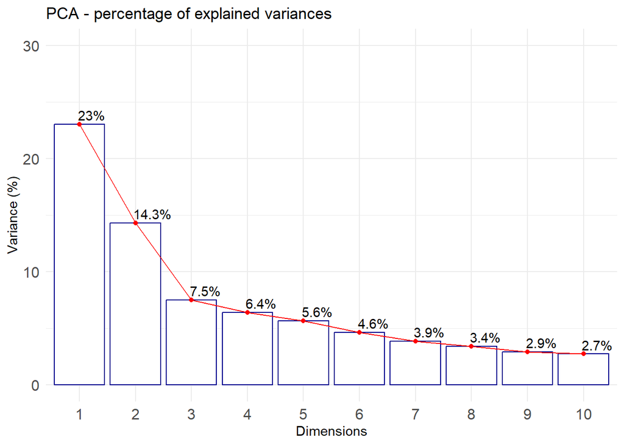

```r
p1 <- fviz_eig(mv,
                addlabels=TRUE,
                hjust = 0.05,
                barfill="white",
                barcolor ="darkblue",
                linecolor ="red") +
  ylim(0, 30) +
  labs(
    title = "PCA - percentage of explained variances",
    y = "Variance (%)") +
  theme_minimal()  +
  theme(
    axis.text.x = element_text(size = 12)
    , axis.text.y = element_text(size = 12)
  )

p1
```

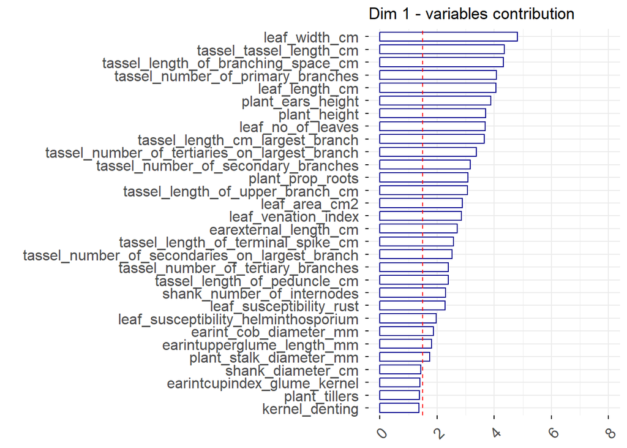

```r
p2 <- fviz_contrib(mv,
                     choice = "var",
                     axes = 1,
                     top = 30,
                     fill="white",
                     color ="darkblue"
                   , sort.val = "asc"
                   ) +
  ylim(0, 8) +
  labs(title = "Dim 1 - variables contribution", x = "") +
  coord_flip()  +
  theme(
    axis.text.x = element_text(size = 12)
    , axis.text.y = element_text(size = 12)
  )

p2
```

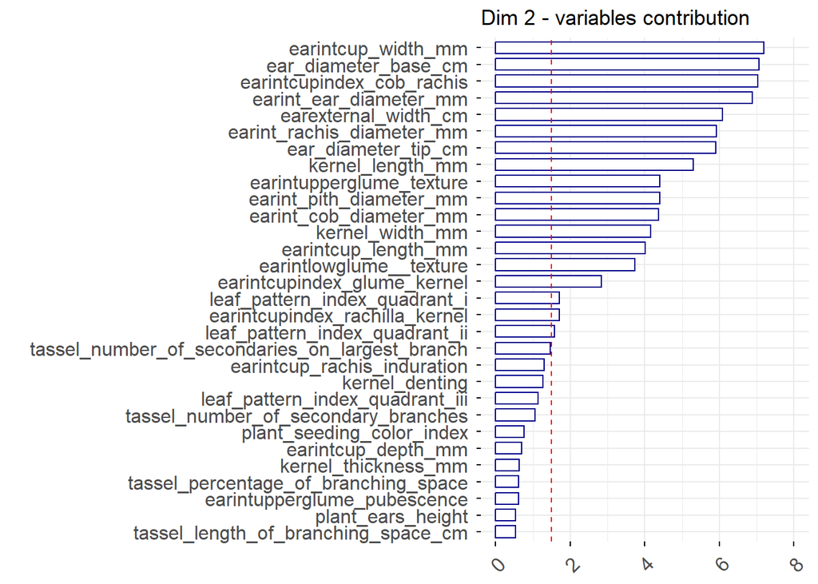

```r
p3 <- fviz_contrib(mv,
                     choice = "var",
                     axes = 2,
                     top = 30,
                     fill="white",
                     color ="darkblue"
                   , sort.val = "asc"
                   ) +
  ylim(0, 8) +
  labs(title = "Dim 2 - variables contribution", x = "") +
  coord_flip()  +
  theme(
    axis.text.x = element_text(size = 12)
    , axis.text.y = element_text(size = 12)
  )

p3
```

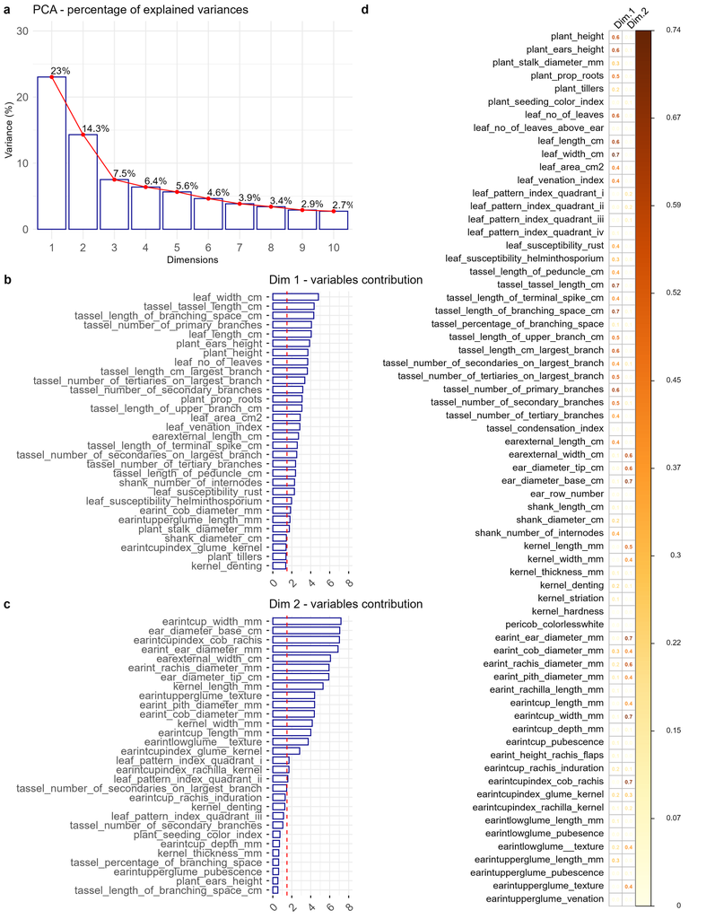

```r
panel_a <- c(p1, p2, p3) %>%
  plot_grid(plotlist = ., ncol = 1, labels = "auto", rel_heights = c(1, 1.2, 1.2))

p4 <- \() {

pcainfo$cos2[, 1:2] %>%
  corrplot(
    is.corr = F
    , method = "number",
    type = "full",
    tl.col = "black",
    tl.srt = 45,
    tl.cex = 0.9,
    number.cex = 0.5,
    number.digits = 1,
    cl.cex = 0.7,
    cl.pos = "r",
    cl.align = "r",
    cl.ratio = 4
  )

}

grid <- c(panel_a, p4) %>%
  plot_grid(plotlist = ., ncol = 2, labels = c("", "d"))

plot <- grid %>%
  ggsave(plot = ., "manuscript/Figure-1.jpg"
         , units = "cm"
         , width = 28, height = 36)

plot %>% include_graphics()
```

# 6 Descriptors with most to phenotypic differentiation

```r
# ============================================================
# 1. Datos de PCA
# ============================================================

contrib <- pcainfo$contrib %>%
  as.data.frame() %>%
  rownames_to_column("variable")

cos2 <- pcainfo$cos2 %>%
  as.data.frame() %>%
  rownames_to_column("variable")

# ============================================================
# 2. Selección inicial de variables
# ============================================================

n_traits <- 68

expected_contrib <- 100 / n_traits

contrib_selected <- contrib %>%
  dplyr::select(variable, Dim.1, Dim.2) %>%
  pivot_longer(!c(variable)) %>%
  dplyr::filter(value > expected_contrib) %>%
  rename(contribution = value)

cos_selected <- cos2 %>%
  dplyr::select(variable, Dim.1, Dim.2) %>%
  pivot_longer(!c(variable)) %>%
  dplyr::filter(value > 0.6) %>%
  rename(cos2 = value)

selection_table <- merge(contrib_selected, cos_selected)


selection_table %>% kable()
```

| variable | name | contribution | cos2 |
| --- | --- | --- | --- |
| ear_diameter_base_cm | Dim.2 | 7.059928 | 0.6771211 |
| earint_ear_diameter_mm | Dim.2 | 6.878159 | 0.6596875 |
| earintcup_width_mm | Dim.2 | 7.188305 | 0.6894338 |
| earintcupindex_cob_rachis | Dim.2 | 7.024832 | 0.6737550 |
| leaf_length_cm | Dim.1 | 4.051485 | 0.6253715 |
| leaf_width_cm | Dim.1 | 4.810575 | 0.7425418 |
| tassel_length_of_branching_space_cm | Dim.1 | 4.320677 | 0.6669229 |
| tassel_number_of_primary_branches | Dim.1 | 4.072620 | 0.6286338 |
| tassel_tassel_length_cm | Dim.1 | 4.355120 | 0.6722394 |

```r
selected_traits <- selection_table %>%
  pluck(1) %>%
  unique()

traits <- range_read(gs, "STable2x")

table2 <- merge(selection_table, traits) %>%
  dplyr::select(Trait, variable, Unit:Max, everything())

# table2 %>% range_write(gs, .,  "Table2")
```

## 6.1 RO 2

```r
dtsl <- fb %>%
  dplyr::select(race, group, {{selected_traits}})

mv <- dtsl %>%
  column_to_rownames("race") %>%
  mutate(across(group, ~ as.factor(.))) %>%
  PCA(X = ., scale.unit = T, graph = F, quali.sup = c(1))

pcainfo <- factoextra::get_pca(mv); pcainfo
```

```
Principal Component Analysis Results for variables
 ===================================================
  Name       Description
1 "$coord"   "Coordinates for the variables"
2 "$cor"     "Correlations between variables and dimensions"
3 "$cos2"    "Cos2 for the variables"
4 "$contrib" "contributions of the variables"
```

```r
pcainfo$cor %>% kable(caption = "Variable correlations")
```

Variable correlations

|  | Dim.1 | Dim.2 | Dim.3 | Dim.4 | Dim.5 |
| --- | --- | --- | --- | --- | --- |
| ear_diameter_base_cm | 0.4434870 | 0.7875535 | 0.3268558 | 0.1541004 | 0.0945557 |
| earint_ear_diameter_mm | 0.3986324 | 0.8191631 | 0.2809975 | 0.1187529 | 0.1369916 |
| earintcup_width_mm | 0.4158414 | 0.7564282 | -0.3900313 | 0.0276753 | 0.0659855 |
| earintcupindex_cob_rachis | -0.3123416 | -0.8027550 | 0.2286344 | 0.1704063 | 0.3762325 |
| leaf_length_cm | 0.8308622 | -0.2229874 | -0.0134729 | -0.3969653 | 0.1650893 |
| leaf_width_cm | 0.8764481 | -0.1870160 | -0.0155151 | -0.3076347 | 0.1211355 |
| tassel_length_of_branching_space_cm | 0.8107652 | -0.4328769 | 0.0179191 | 0.3054413 | -0.0798985 |
| tassel_number_of_primary_branches | 0.7914000 | -0.3731171 | 0.3139275 | -0.0047146 | -0.3097609 |
| tassel_tassel_length_cm | 0.7644579 | -0.3213711 | -0.3421325 | 0.3683335 | 0.0786417 |

```r
pcainfo$contrib %>% kable(caption = "Variable Contribution")
```

Variable Contribution

|  | Dim.1 | Dim.2 | Dim.3 | Dim.4 | Dim.5 |
| --- | --- | --- | --- | --- | --- |
| ear_diameter_base_cm | 4.975967 | 20.521157 | 17.6137714 | 4.3265937 | 2.758983 |
| earint_ear_diameter_mm | 4.020321 | 22.201507 | 13.0180162 | 2.5693704 | 5.791108 |
| earintcup_width_mm | 4.374930 | 18.931153 | 25.0806560 | 0.1395476 | 1.343602 |
| earintcupindex_cob_rachis | 2.468172 | 21.321008 | 8.6183320 | 5.2906541 | 43.680340 |
| leaf_length_cm | 17.465207 | 1.645138 | 0.0299268 | 28.7106823 | 8.410301 |
| leaf_width_cm | 19.434264 | 1.157176 | 0.0396871 | 17.2428416 | 4.528100 |
| tassel_length_of_branching_space_cm | 16.630521 | 6.199696 | 0.0529385 | 16.9978417 | 1.969928 |
| tassel_number_of_primary_branches | 15.845567 | 4.606085 | 16.2479490 | 0.0040497 | 29.609197 |
| tassel_tassel_length_cm | 14.785051 | 3.417081 | 19.2987230 | 24.7184188 | 1.908441 |

```r
pcainfo$cos2 %>% kable(caption = "Variable Cos2")
```

Variable Cos2

|  | Dim.1 | Dim.2 | Dim.3 | Dim.4 | Dim.5 |
| --- | --- | --- | --- | --- | --- |
| ear_diameter_base_cm | 0.1966807 | 0.6202406 | 0.1068347 | 0.0237469 | 0.0089408 |
| earint_ear_diameter_mm | 0.1589078 | 0.6710282 | 0.0789596 | 0.0141022 | 0.0187667 |
| earintcup_width_mm | 0.1729240 | 0.5721836 | 0.1521244 | 0.0007659 | 0.0043541 |
| earintcupindex_cob_rachis | 0.0975573 | 0.6444156 | 0.0522737 | 0.0290383 | 0.1415509 |
| leaf_length_cm | 0.6903321 | 0.0497234 | 0.0001815 | 0.1575815 | 0.0272545 |
| leaf_width_cm | 0.7681613 | 0.0349750 | 0.0002407 | 0.0946391 | 0.0146738 |
| tassel_length_of_branching_space_cm | 0.6573402 | 0.1873824 | 0.0003211 | 0.0932944 | 0.0063838 |
| tassel_number_of_primary_branches | 0.6263140 | 0.1392164 | 0.0985505 | 0.0000222 | 0.0959518 |
| tassel_tassel_length_cm | 0.5843959 | 0.1032794 | 0.1170546 | 0.1356695 | 0.0061845 |

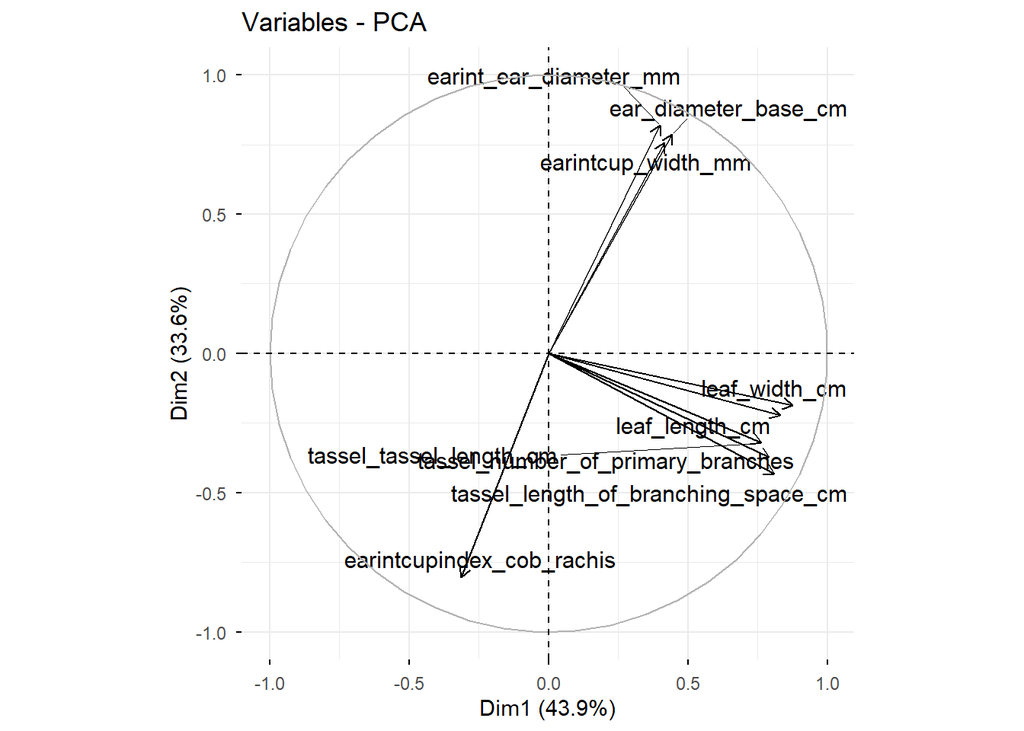

```r
var <- fviz_pca_var(mv
                    , repel = TRUE
                    , labelsize = 4
                    )

var
```

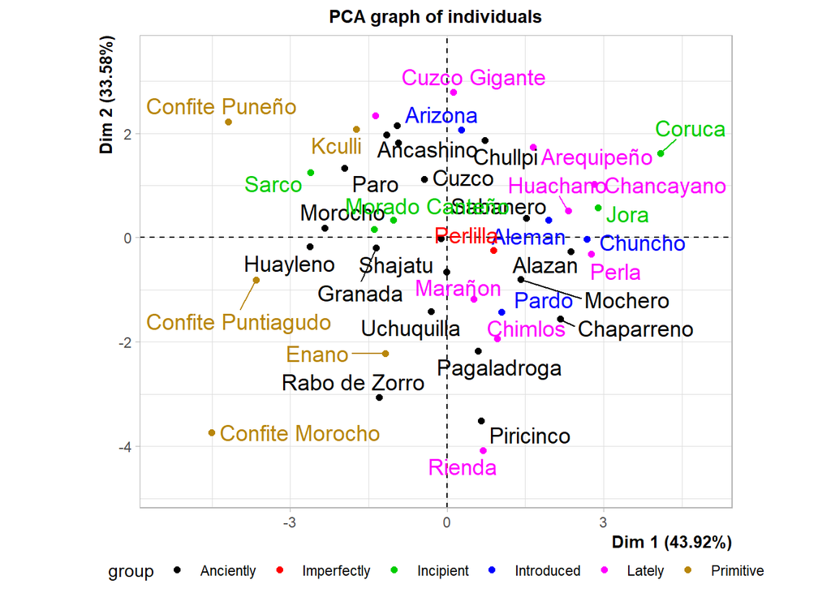

```r
ind <- plot.PCA(mv, choix = c("ind")
                , cex = 1.2
                , label = "ind"
                , invisible = "quali"
                , habillage = 1
                )  +
  theme(
    legend.position = "bottom",       # leyenda abajo
    legend.direction = "horizontal"   # en una sola línea
  ) + guides(color = guide_legend(nrow = 1))

ind
```

```r
cls <- HCPC(mv, graph = F, nb.clust = -1)

cls$call$t$tree
```

```
Call:
flashClust::hclust(d = dissi, method = method, members = weight)

Cluster method   : ward
Distance         : euclidean
Number of objects: 43
```

```r
cls$data.clust %>% kable(caption = "Cluster membership of each individual")
```

Cluster membership of each individual

|  | group | ear_diameter_base_cm | earint_ear_diameter_mm | earintcup_width_mm | earintcupindex_cob_rachis | leaf_length_cm | leaf_width_cm | tassel_length_of_branching_space_cm | tassel_number_of_primary_branches | tassel_tassel_length_cm | clust |
| --- | --- | --- | --- | --- | --- | --- | --- | --- | --- | --- | --- |
| Confite Morocho | Primitive | 2.690000 | 26.30000 | 2.900000 | 2.300000 | 53.4 | 6.3 | 9.40000 | 10.70000 | 28.7000 | 1 |
| Confite Puntiagudo | Primitive | 3.340000 | 33.50000 | 5.100000 | 1.710000 | 56.2 | 6.5 | 9.10000 | 9.00000 | 24.7000 | 1 |
| Kculli | Primitive | 4.710000 | 46.90000 | 8.100000 | 1.400000 | 58.0 | 7.4 | 8.80000 | 10.30000 | 27.2000 | 2 |
| Confite Puneño | Primitive | 4.460000 | 44.50000 | 7.400000 | 1.540000 | 52.3 | 5.7 | 4.40000 | 5.90000 | 18.7000 | 1 |
| Enano | Primitive | 2.700000 | 43.83947 | 3.700000 | 1.830000 | 73.7 | 7.7 | 13.80244 | 16.66829 | 33.2375 | 3 |
| Huayleno | Anciently | 4.200000 | 42.00000 | 5.300000 | 1.840000 | 61.6 | 7.7 | 8.20000 | 14.90000 | 19.1000 | 1 |
| Chullpi | Anciently | 5.860000 | 58.00000 | 7.100000 | 1.600000 | 72.0 | 8.2 | 14.60000 | 18.00000 | 28.5000 | 2 |
| Granada | Anciently | 4.180000 | 42.60000 | 6.900000 | 1.740000 | 66.6 | 6.9 | 13.60000 | 15.20000 | 27.7000 | 2 |
| Paro | Anciently | 4.670000 | 43.30000 | 7.500000 | 1.460000 | 36.2 | 6.9 | 12.00000 | 11.50000 | 33.0000 | 2 |
| Morocho | Anciently | 3.730000 | 37.30000 | 8.200000 | 1.690000 | 59.0 | 8.7 | 7.80000 | 9.90000 | 24.8000 | 1 |
| Huancavelicano | Anciently | 4.700000 | 46.50000 | 10.800000 | 1.580000 | 55.1 | 8.3 | 9.20000 | 11.80000 | 28.7000 | 2 |
| Mochero | Anciently | 4.060000 | 41.30000 | 7.900000 | 1.540000 | 75.8 | 8.8 | 16.80000 | 23.60000 | 37.9000 | 4 |
| Pagaladroga | Anciently | 3.700000 | 34.90000 | 5.900000 | 1.740000 | 76.2 | 9.7 | 16.20000 | 21.50000 | 33.7000 | 3 |
| Chaparreno | Anciently | 4.280000 | 41.10000 | 6.500000 | 1.650000 | 90.2 | 9.2 | 15.80000 | 25.80000 | 43.1000 | 4 |
| Rabo de Zorro | Anciently | 3.500000 | 34.80000 | 4.600000 | 2.170000 | 61.1 | 8.7 | 15.60000 | 16.00000 | 32.8000 | 3 |
| Piricinco | Anciently | 3.630000 | 30.50000 | 4.100000 | 1.880000 | 77.9 | 9.3 | 17.90000 | 25.00000 | 35.5000 | 3 |
| Ancashino | Anciently | 5.280000 | 49.50000 | 6.700000 | 1.460000 | 55.9 | 8.2 | 10.60000 | 15.70000 | 25.2000 | 2 |
| Shajatu | Anciently | 4.500000 | 44.00000 | 6.200000 | 1.720000 | 63.5 | 7.4 | 16.90000 | 18.80000 | 36.4000 | 3 |
| Alazan | Anciently | 4.300000 | 42.80000 | 10.300000 | 1.560000 | 87.2 | 9.9 | 16.60000 | 23.60000 | 36.9000 | 4 |
| Sabanero | Anciently | 4.630000 | 42.20000 | 10.100000 | 1.530000 | 86.7 | 9.5 | 16.30000 | 16.30000 | 34.1000 | 4 |
| Uchuquilla | Anciently | 3.290000 | 33.80000 | 8.600000 | 1.640000 | 58.7 | 7.7 | 16.50000 | 17.50000 | 40.5000 | 3 |
| Cuzco Cristalino Amarillo | Anciently | 3.840000 | 40.10000 | 8.400000 | 1.520000 | 73.8 | 9.4 | 13.90000 | 12.60000 | 30.8000 | 2 |
| Cuzco | Anciently | 4.600000 | 46.50000 | 9.800000 | 1.660000 | 64.3 | 8.9 | 11.90000 | 12.90000 | 29.3000 | 2 |
| Pisccorunto | Anciently | 4.970000 | 51.50000 | 8.500000 | 1.520000 | 76.2 | 7.4 | 8.30000 | 7.80000 | 33.2375 | 2 |
| Arequipeño | Lately | 5.370000 | 51.70000 | 10.000000 | 1.470000 | 81.0 | 9.1 | 15.10000 | 18.40000 | 32.0000 | 4 |
| Huachano | Lately | 5.000000 | 50.10000 | 9.600000 | 1.610000 | 81.9 | 9.5 | 17.40000 | 19.20000 | 40.2000 | 4 |
| Chancayano | Lately | 5.110000 | 49.40000 | 11.500000 | 1.560000 | 87.0 | 10.2 | 15.40000 | 18.80000 | 42.4000 | 4 |
| San Geronimo Huancavelicano | Lately | 5.200000 | 49.30000 | 9.900000 | 1.550000 | 55.1 | 6.6 | 11.60000 | 15.00000 | 23.2000 | 2 |
| Perla | Lately | 4.740000 | 45.00000 | 9.200000 | 1.630000 | 94.4 | 10.6 | 16.50000 | 20.80000 | 39.3000 | 4 |
| Rienda | Lately | 3.620000 | 34.70000 | 4.100000 | 2.170000 | 70.6 | 9.1 | 20.80000 | 20.50000 | 43.3000 | 3 |
| Marañon | Lately | 4.330000 | 41.20000 | 5.700000 | 1.730000 | 76.0 | 9.1 | 15.00000 | 18.60000 | 36.2000 | 3 |
| Chimlos | Lately | 4.510000 | 41.80000 | 4.500000 | 1.890000 | 76.9 | 9.7 | 15.80000 | 23.70000 | 34.2000 | 3 |
| Cuzco Gigante | Lately | 5.930000 | 56.80000 | 11.200000 | 1.680000 | 51.8 | 7.6 | 13.80000 | 12.30000 | 36.0000 | 2 |
| Pardo | Introduced | 3.830000 | 38.60000 | 7.900000 | 1.710000 | 81.3 | 8.9 | 17.70000 | 12.90000 | 46.2000 | 3 |
| Aleman | Introduced | 4.980000 | 46.90000 | 8.500000 | 1.560000 | 85.3 | 9.7 | 15.20000 | 20.40000 | 36.4000 | 4 |
| Chuncho | Introduced | 5.210000 | 49.50000 | 7.500000 | 1.620000 | 82.4 | 10.5 | 16.90000 | 24.90000 | 36.0000 | 4 |
| Arizona | Introduced | 5.070000 | 49.90000 | 10.900000 | 1.480000 | 55.9 | 8.2 | 12.10000 | 16.50000 | 36.1000 | 2 |
| Jora | Incipient | 4.860000 | 50.10000 | 9.200000 | 1.430000 | 83.2 | 9.9 | 17.20000 | 21.10000 | 43.6000 | 4 |
| Coruca | Incipient | 5.970000 | 57.00000 | 10.300000 | 1.460000 | 91.0 | 10.4 | 19.20000 | 23.80000 | 39.0000 | 4 |
| Morocho Cajabambino | Incipient | 3.840000 | 43.83947 | 7.707692 | 1.662308 | 58.1 | 7.9 | 11.50000 | 15.80000 | 27.4000 | 2 |
| Morado Canteño | Incipient | 4.443415 | 43.83947 | 7.707692 | 1.662308 | 53.5 | 7.2 | 13.30000 | 12.80000 | 37.6000 | 2 |
| Sarco | Incipient | 4.790000 | 43.83947 | 7.707692 | 1.662308 | 40.3 | 6.5 | 11.00000 | 13.60000 | 23.1000 | 2 |
| Perlilla | Imperfectly | 4.443415 | 43.83947 | 7.707692 | 1.662308 | 84.0 | 9.8 | 13.80244 | 16.66829 | 33.2375 | 4 |

```r
cls$desc.var$quanti %>% kable(caption = "Quantitative variables characterizing each cluster")
```

Quantitative variables characterizing each cluster

|  | v.test | Mean in category | Overall mean | sd in category | Overall sd | p.value | n |
| --- | --- | --- | --- | --- | --- | --- | --- |
| earintcup_width_mm | -2.090975 | 5.780 | 7.707692 | 1.8691174 | 2.1672386 | 0.0365303 | 5 |
| leaf_length_cm | -2.115279 | 56.500 | 69.332558 | 3.4525353 | 14.2614413 | 0.0344062 | 5 |
| ear_diameter_base_cm | -2.340941 | 3.684 | 4.443415 | 0.6287957 | 0.7626167 | 0.0192352 | 5 |
| earint_ear_diameter_mm | -2.458062 | 36.720 | 43.839474 | 6.4449670 | 6.8088362 | 0.0139689 | 5 |
| leaf_width_cm | -2.805661 | 6.980 | 8.486047 | 1.0777755 | 1.2618888 | 0.0050214 | 5 |
| tassel_number_of_primary_branches | -3.126925 | 10.080 | 16.668293 | 2.9081953 | 4.9530559 | 0.0017664 | 5 |
| tassel_tassel_length_cm | -3.593607 | 23.200 | 33.237500 | 3.7978942 | 6.5661814 | 0.0003261 | 5 |
| tassel_length_of_branching_space_cm | -4.037531 | 7.780 | 13.802439 | 1.7870646 | 3.5065048 | 0.0000540 | 5 |

|  | v.test | Mean in category | Overall mean | sd in category | Overall sd | p.value | n |
| --- | --- | --- | --- | --- | --- | --- | --- |
| earint_ear_diameter_mm | 2.546339 | 47.494561 | 43.839474 | 4.9309087 | 6.8088362 | 0.0108860 | 15 |
| ear_diameter_base_cm | 2.252522 | 4.805561 | 4.443415 | 0.5956559 | 0.7626167 | 0.0242893 | 15 |
| earintcupindex_cob_rachis | -2.146730 | 1.575795 | 1.662308 | 0.0972140 | 0.1911588 | 0.0318148 | 15 |
| tassel_tassel_length_cm | -2.481448 | 29.802500 | 33.237500 | 4.4099608 | 6.5661814 | 0.0130850 | 15 |
| tassel_length_of_branching_space_cm | -2.780941 | 11.746667 | 13.802439 | 1.8629248 | 3.5065048 | 0.0054202 | 15 |
| leaf_width_cm | -2.929674 | 7.706667 | 8.486047 | 0.8103223 | 1.2618888 | 0.0033932 | 15 |
| tassel_number_of_primary_branches | -3.078885 | 13.453333 | 16.668293 | 2.5458114 | 4.9530559 | 0.0020778 | 15 |
| leaf_length_cm | -3.707171 | 58.186667 | 69.332558 | 10.8409020 | 14.2614413 | 0.0002096 | 15 |

|  | v.test | Mean in category | Overall mean | sd in category | Overall sd | p.value | n |
| --- | --- | --- | --- | --- | --- | --- | --- |
| earintcupindex_cob_rachis | 3.465511 | 1.84800 | 1.662308 | 0.1774148 | 0.1911588 | 0.0005292 | 10 |
| tassel_length_of_branching_space_cm | 2.866845 | 16.62024 | 13.802439 | 1.8116912 | 3.5065048 | 0.0041459 | 10 |
| tassel_tassel_length_cm | 2.154939 | 37.20375 | 33.237500 | 4.3582252 | 6.5661814 | 0.0311666 | 10 |
| earint_ear_diameter_mm | -3.157110 | 37.81395 | 43.839474 | 4.4656836 | 6.8088362 | 0.0015934 | 10 |
| ear_diameter_base_cm | -3.192344 | 3.76100 | 4.443415 | 0.5377816 | 0.7626167 | 0.0014112 | 10 |
| earintcup_width_mm | -3.584738 | 5.53000 | 7.707692 | 1.5818028 | 2.1672386 | 0.0003374 | 10 |

|  | v.test | Mean in category | Overall mean | sd in category | Overall sd | p.value | n |
| --- | --- | --- | --- | --- | --- | --- | --- |
| leaf_length_cm | 4.804089 | 85.392308 | 69.332558 | 4.6613734 | 14.2614413 | 0.0000016 | 13 |
| leaf_width_cm | 4.364146 | 9.776923 | 8.486047 | 0.5337153 | 1.2618888 | 0.0000128 | 13 |
| tassel_number_of_primary_branches | 3.755370 | 21.028330 | 16.668293 | 2.9833287 | 4.9530559 | 0.0001731 | 13 |
| tassel_tassel_length_cm | 3.101139 | 38.010577 | 33.237500 | 3.5726520 | 6.5661814 | 0.0019278 | 13 |
| tassel_length_of_branching_space_cm | 3.066931 | 16.323265 | 13.802439 | 1.2743256 | 3.5065048 | 0.0021627 | 13 |
| earintcup_width_mm | 2.741882 | 9.100592 | 7.707692 | 1.3524484 | 2.1672386 | 0.0061088 | 13 |
| ear_diameter_base_cm | 2.232913 | 4.842570 | 4.443415 | 0.4990833 | 0.7626167 | 0.0255547 | 13 |
| earint_ear_diameter_mm | 1.977343 | 46.995344 | 43.839474 | 4.6018278 | 6.8088362 | 0.0480029 | 13 |
| earintcupindex_cob_rachis | -2.279269 | 1.560177 | 1.662308 | 0.0711804 | 0.1911588 | 0.0226511 | 13 |

```r
cls$desc.var$category%>% kable(caption = "Categorical variables significantly by cluster")
```

Categorical variables significantly by cluster

|  | Cla/Mod | Mod/Cla | Global | p.value | v.test |
| --- | --- | --- | --- | --- | --- |
| group=Primitive | 60 | 60 | 11.62791 | 0.0077 | 2.664949 |

```r
table(cls$data.clust$clust) %>% kable(caption = "Number of individuals assigned to each cluster")
```

Number of individuals assigned to each cluster

| Var1 | Freq |
| --- | --- |
| 1 | 5 |
| 2 | 15 |
| 3 | 10 |
| 4 | 13 |

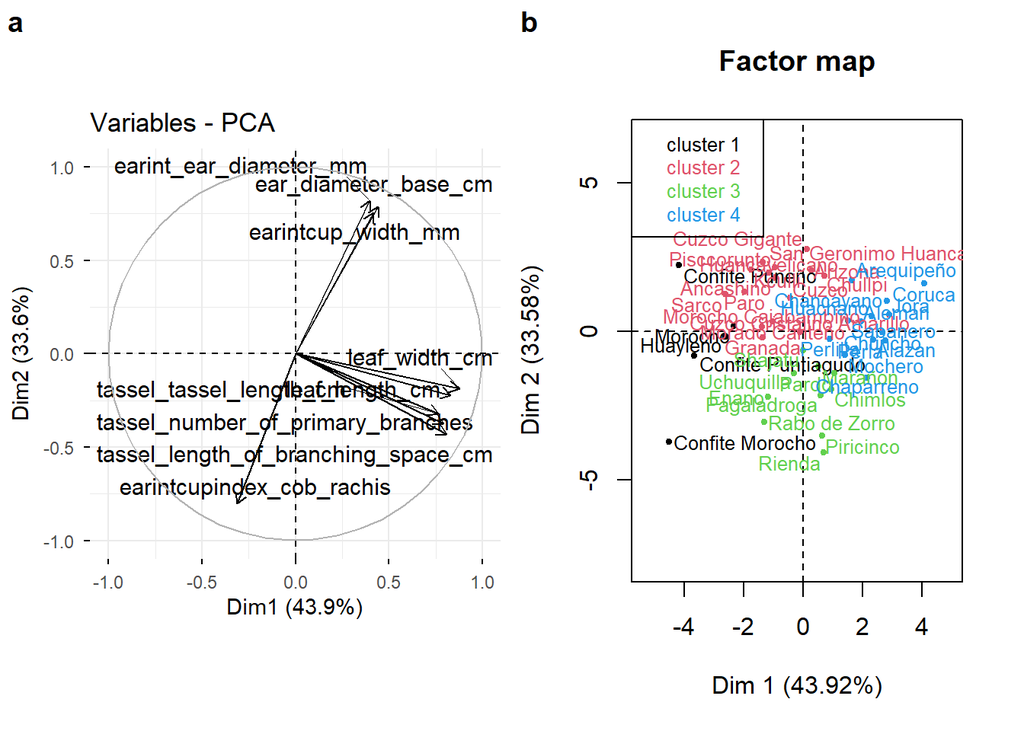

```r
clsp <- function() {

  plot.HCPC(cls, choice = "map", draw.tree = F)

}

grid <- plot_grid(plotlist = list(var, clsp)
                  , ncol = 2, labels = "auto")

grid
```

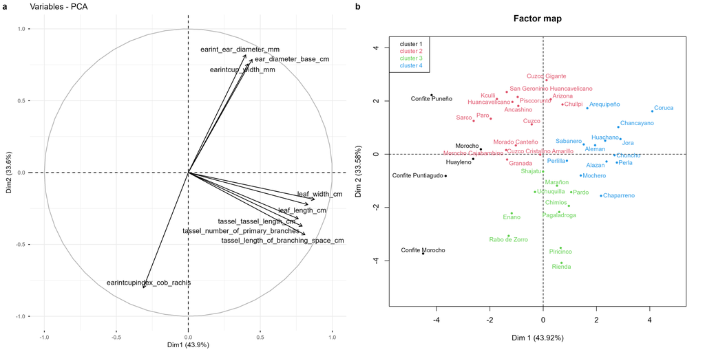

```r
plot <- grid %>%
  ggsave(plot = ., "manuscript/Figure-2.jpg", units = "cm"
                , width = 40, height = 20)

plot %>% include_graphics()
```

## 6.2 RO 3

Comparar con la clasificación de Grobman et al. 1961 (Table 8, Pag. 139):

Grobman, Alexander; Wilfredo Salhuana, Ricardo Sevilla y Paul C. Mangelsdorf. 1961. Races of Maize in Peru: Their Origins, Evolution and Classification. (Publication 915). Washington, D.C.: National Academy of Sciences, National Research Council.

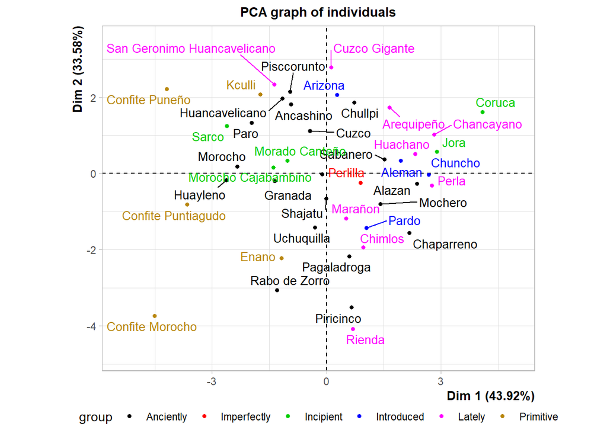

```r
ind <- plot.PCA(mv
                , choix = c("ind")
                , cex = 0.9
                , label = "ind"
                , invisible = "quali"
                , habillage = 1
                )  +
  theme(
    legend.position = "bottom",
    legend.direction = "horizontal"
  ) + guides(color = guide_legend(nrow = 1))

ind
```

```r
infoind <- mv %>%
  get_pca_ind()

infoind$coord %>% kable(caption = "Coordinates for the individuals")
```

Coordinates for the individuals

|  | Dim.1 | Dim.2 | Dim.3 | Dim.4 | Dim.5 |
| --- | --- | --- | --- | --- | --- |
| Confite Morocho | -4.5054286 | -3.7322642 | 0.0387314 | 0.2577222 | 0.9896147 |
| Confite Puntiagudo | -3.6598891 | -0.8157309 | -0.5157416 | -0.5744656 | -0.3312575 |
| Kculli | -1.7370946 | 2.0781477 | -0.3008638 | -0.4180743 | -0.3604432 |
| Confite Puneño | -4.1875357 | 2.2234250 | 0.0266221 | -0.7680877 | 0.0249661 |
| Enano | -1.1811871 | -2.2175352 | 0.2312955 | -0.2482500 | -0.0580364 |
| Huayleno | -2.6265376 | -0.1754797 | 1.3848021 | -1.1151067 | 0.1988277 |
| Chullpi | 0.7245077 | 1.8693362 | 2.0065439 | 0.3615529 | 0.2892040 |
| Granada | -1.3553364 | -0.1983945 | 0.3733262 | 0.1619142 | -0.1458832 |
| Paro | -1.9672779 | 1.3360503 | -0.5179010 | 1.3455776 | -0.9865466 |
| Morocho | -2.3406654 | 0.1873469 | -0.8269186 | -1.3248456 | 0.3678358 |
| Huancavelicano | -1.1548049 | 1.9655240 | -0.6613964 | -0.1956143 | 0.3335346 |
| Mochero | 1.4100801 | -0.7988413 | -0.3188014 | 0.0420551 | -1.1847927 |
| Pagaladroga | 0.6005533 | -2.1686857 | 0.0047135 | -0.6976747 | -0.5786308 |
| Chaparreno | 2.1697558 | -1.5630912 | 0.0849109 | -0.1937479 | -0.5704967 |
| Rabo de Zorro | -1.2960971 | -3.0667590 | 0.4929028 | 0.5051859 | 0.9250465 |
| Piricinco | 0.6562053 | -3.5185346 | 0.5437954 | -0.2834898 | -0.8091938 |
| Ancashino | -0.9340807 | 1.8158556 | 1.1412511 | -0.2844205 | -0.6270061 |
| Shajatu | -0.0052133 | -0.6536377 | 0.4830886 | 1.2400837 | -0.4565597 |
| Alazan | 2.3761741 | -0.2729024 | -0.5967176 | -0.6812593 | -0.4777154 |
| Sabanero | 1.5204524 | 0.3689499 | -0.8485623 | -0.7324131 | 0.1359934 |
| Uchuquilla | -0.3088945 | -1.4162769 | -1.7824024 | 0.9617402 | -1.0307640 |
| Cuzco Cristalino Amarillo | -0.1109979 | -0.0145945 | -1.0959714 | -1.0483803 | -0.0818571 |
| Cuzco | -0.4295600 | 1.1219515 | -0.3160279 | -0.3254872 | 0.6068256 |
| Pisccorunto | -0.9577859 | 2.1515381 | -0.4549093 | -0.3698121 | 1.0868291 |
| Arequipeño | 1.6557875 | 1.7294904 | 0.3098086 | -0.3378629 | 0.0099217 |
| Huachano | 2.3248666 | 0.5094799 | -0.1469831 | 0.4099580 | 0.4137500 |
| Chancayano | 2.8189731 | 1.0204770 | -0.8494819 | -0.0939541 | 0.7337524 |
| San Geronimo Huancavelicano | -1.3679835 | 2.3387543 | 0.5950189 | 0.3761062 | -0.4604632 |
| Perla | 2.7653871 | -0.3127845 | -0.2851834 | -0.7714875 | 0.5056165 |
| Rienda | 0.6872180 | -4.0821488 | 0.3491910 | 1.4390428 | 0.6999408 |
| Marañon | 0.5175723 | -1.1810492 | 0.3146934 | -0.1361260 | 0.0499576 |
| Chimlos | 0.9623613 | -1.9407325 | 1.5120999 | -0.1962481 | 0.0844636 |
| Cuzco Gigante | 0.1261096 | 2.7832264 | 0.2199799 | 1.9568551 | 1.0619899 |
| Pardo | 1.0504675 | -1.4248735 | -1.7558056 | 0.6287879 | 0.7002504 |
| Aleman | 1.9472708 | 0.3396642 | 0.1800169 | -0.4914493 | 0.0437356 |
| Chuncho | 2.6757293 | -0.0360374 | 1.1626135 | -0.3030321 | -0.1552158 |
| Arizona | 0.2822274 | 2.0656469 | -0.5472479 | 0.7648386 | -0.2834272 |
| Jora | 2.8996215 | 0.5711714 | -0.4900820 | 0.1993051 | -0.2957757 |
| Coruca | 4.0924630 | 1.6141076 | 0.8015556 | 0.1453489 | 0.1218843 |
| Morocho Cajabambino | -1.3897916 | 0.1580015 | -0.0044166 | -0.2613106 | -0.3939310 |
| Morado Canteño | -1.0270884 | 0.3325020 | -0.5704646 | 1.2942604 | -0.0019557 |
| Sarco | -2.6093768 | 1.2536316 | 0.6674530 | 0.7457202 | -0.6138230 |
| Perlilla | 0.8888433 | -0.2439248 | -0.0385354 | -0.9834553 | 0.5198342 |

```r
infoind$cos2 %>% kable(caption = "Cos2 for the individuals")
```

Cos2 for the individuals

|  | Dim.1 | Dim.2 | Dim.3 | Dim.4 | Dim.5 |
| --- | --- | --- | --- | --- | --- |
| Confite Morocho | 0.5681742 | 0.3899007 | 0.0000420 | 0.0018591 | 0.0274121 |
| Confite Puntiagudo | 0.8858766 | 0.0440080 | 0.0175915 | 0.0218256 | 0.0072572 |
| Kculli | 0.3704323 | 0.5301695 | 0.0111122 | 0.0214570 | 0.0159491 |
| Confite Puneño | 0.7443287 | 0.2098421 | 0.0000301 | 0.0250420 | 0.0000265 |
| Enano | 0.1409696 | 0.4968545 | 0.0054053 | 0.0062268 | 0.0003403 |
| Huayleno | 0.6716627 | 0.0029980 | 0.1867065 | 0.1210645 | 0.0038489 |
| Chullpi | 0.0603936 | 0.4020494 | 0.4632356 | 0.0150400 | 0.0096231 |
| Granada | 0.6388421 | 0.0136886 | 0.0484704 | 0.0091174 | 0.0074013 |
| Paro | 0.4050319 | 0.1868114 | 0.0280706 | 0.1894852 | 0.1018575 |
| Morocho | 0.6174882 | 0.0039559 | 0.0770683 | 0.1978247 | 0.0152496 |
| Huancavelicano | 0.1998996 | 0.5790972 | 0.0655720 | 0.0057358 | 0.0166754 |
| Mochero | 0.4656268 | 0.1494416 | 0.0238008 | 0.0004142 | 0.3287268 |
| Pagaladroga | 0.0589671 | 0.7689528 | 0.0000036 | 0.0795816 | 0.0547406 |
| Chaparreno | 0.5252425 | 0.2725880 | 0.0008044 | 0.0041881 | 0.0363115 |
| Rabo de Zorro | 0.1287242 | 0.7206830 | 0.0186169 | 0.0195563 | 0.0655710 |
| Piricinco | 0.0304646 | 0.8758702 | 0.0209212 | 0.0056858 | 0.0463256 |
| Ancashino | 0.1334115 | 0.5041817 | 0.1991530 | 0.0123693 | 0.0601129 |
| Shajatu | 0.0000101 | 0.1590246 | 0.0868648 | 0.5723899 | 0.0775863 |
| Alazan | 0.7521056 | 0.0099206 | 0.0474307 | 0.0618226 | 0.0303991 |
| Sabanero | 0.5166973 | 0.0304246 | 0.1609378 | 0.1198955 | 0.0041336 |
| Uchuquilla | 0.0128386 | 0.2698952 | 0.4274746 | 0.1244556 | 0.1429609 |
| Cuzco Cristalino Amarillo | 0.0040798 | 0.0000705 | 0.3977501 | 0.3639566 | 0.0022188 |
| Cuzco | 0.0711906 | 0.4856497 | 0.0385324 | 0.0408736 | 0.1420701 |
| Pisccorunto | 0.1011275 | 0.5103059 | 0.0228130 | 0.0150763 | 0.1302132 |
| Arequipeño | 0.4464808 | 0.4871133 | 0.0156308 | 0.0185898 | 0.0000160 |
| Huachano | 0.8896008 | 0.0427222 | 0.0035558 | 0.0276616 | 0.0281757 |
| Chancayano | 0.7569076 | 0.0991899 | 0.0687336 | 0.0008408 | 0.0512814 |
| San Geronimo Huancavelicano | 0.2063154 | 0.6030303 | 0.0390330 | 0.0155952 | 0.0233754 |
| Perla | 0.8770854 | 0.0112207 | 0.0093278 | 0.0682634 | 0.0293206 |
| Rienda | 0.0236534 | 0.8346075 | 0.0061070 | 0.1037175 | 0.0245373 |
| Marañon | 0.1285687 | 0.6694669 | 0.0475301 | 0.0088936 | 0.0011978 |
| Chimlos | 0.1272999 | 0.5177060 | 0.3142772 | 0.0052937 | 0.0009806 |
| Cuzco Gigante | 0.0012245 | 0.5964460 | 0.0037260 | 0.2948434 | 0.0868390 |
| Pardo | 0.1408845 | 0.2592094 | 0.3935962 | 0.0504785 | 0.0626044 |
| Aleman | 0.8912209 | 0.0271164 | 0.0076166 | 0.0567662 | 0.0004496 |
| Chuncho | 0.8075363 | 0.0001465 | 0.1524574 | 0.0103575 | 0.0027174 |
| Arizona | 0.0134730 | 0.7217342 | 0.0506563 | 0.0989475 | 0.0135878 |
| Jora | 0.8826307 | 0.0342475 | 0.0252135 | 0.0041700 | 0.0091838 |
| Coruca | 0.8326076 | 0.1295197 | 0.0319402 | 0.0010503 | 0.0007385 |
| Morocho Cajabambino | 0.7115992 | 0.0091973 | 0.0000072 | 0.0251565 | 0.0571711 |
| Morado Canteño | 0.3155568 | 0.0330712 | 0.0973463 | 0.5010779 | 0.0000011 |
| Sarco | 0.6653206 | 0.1535668 | 0.0435310 | 0.0543387 | 0.0368166 |
| Perlilla | 0.3688394 | 0.0277779 | 0.0006933 | 0.4515400 | 0.1261586 |

```r
infoind$contrib %>% kable(caption = "contributions of the individuals")
```

contributions of the individuals

|  | Dim.1 | Dim.2 | Dim.3 | Dim.4 | Dim.5 |
| --- | --- | --- | --- | --- | --- |
| Confite Morocho | 11.9431658 | 10.7181044 | 0.0057517 | 0.2814319 | 7.0280899 |
| Confite Puntiagudo | 7.8810320 | 0.5119965 | 1.0198489 | 1.3982921 | 0.7874745 |
| Kculli | 1.7753915 | 3.3229671 | 0.3470654 | 0.7405883 | 0.9323496 |
| Confite Puneño | 10.3172575 | 3.8038044 | 0.0027174 | 2.4997208 | 0.0044731 |
| Enano | 0.8208894 | 3.7836787 | 0.2051190 | 0.2611249 | 0.0241716 |
| Huayleno | 4.0589573 | 0.0236934 | 7.3527007 | 5.2686909 | 0.2836996 |
| Chullpi | 0.3088398 | 2.6887354 | 15.4372092 | 0.5538773 | 0.6002244 |
| Granada | 1.0807903 | 0.0302854 | 0.5343777 | 0.1110810 | 0.1527268 |
| Paro | 2.2770819 | 1.3734690 | 1.0284070 | 7.6716250 | 6.9845783 |
| Morocho | 3.2234869 | 0.0270064 | 2.6217846 | 7.4370448 | 0.9709861 |
| Huancavelicano | 0.7846292 | 2.9725550 | 1.6772397 | 0.1621329 | 0.7983381 |
| Mochero | 1.1698625 | 0.4910144 | 0.3896835 | 0.0074939 | 10.0737171 |
| Pagaladroga | 0.2122024 | 3.6188156 | 0.0000852 | 2.0624141 | 2.4027469 |
| Chaparreno | 2.7699311 | 1.8799307 | 0.0276438 | 0.1590537 | 2.3356687 |
| Rabo de Zorro | 0.9883763 | 7.2365657 | 0.9315239 | 1.0813651 | 6.1409011 |
| Piricinco | 0.2533534 | 9.5256995 | 1.1338160 | 0.3405217 | 4.6990502 |
| Ancashino | 0.5133530 | 2.5370899 | 4.9938312 | 0.3427613 | 2.8212950 |
| Shajatu | 0.0000160 | 0.3287361 | 0.8947982 | 6.5158615 | 1.4958914 |
| Alazan | 3.3220314 | 0.0573044 | 1.3652405 | 1.9665038 | 1.6377342 |
| Sabanero | 1.3601690 | 0.1047389 | 2.7608251 | 2.2729093 | 0.1327213 |
| Uchuquilla | 0.0561394 | 1.5433683 | 12.1810015 | 3.9190920 | 7.6247130 |
| Cuzco Cristalino Amarillo | 0.0072490 | 0.0001639 | 4.6054267 | 4.6570142 | 0.0480859 |
| Cuzco | 0.1085663 | 0.9685485 | 0.3829327 | 0.4488877 | 2.6426086 |
| Pisccorunto | 0.5397394 | 3.5618145 | 0.7934527 | 0.5794716 | 8.4767137 |
| Arequipeño | 1.6130819 | 2.3014924 | 0.3680089 | 0.4836719 | 0.0007064 |
| Huachano | 3.1801185 | 0.1997227 | 0.0828335 | 0.7121124 | 1.2285163 |
| Chancayano | 4.6755110 | 0.8012715 | 2.7668123 | 0.0374026 | 3.8637063 |
| San Geronimo Huancavelicano | 1.1010549 | 4.2086462 | 1.3574786 | 0.5993644 | 1.5215803 |
| Perla | 4.4994467 | 0.0752773 | 0.3118316 | 2.5218989 | 1.8346260 |
| Rienda | 0.2778666 | 12.8218556 | 0.4675172 | 8.7743969 | 3.5158282 |
| Marañon | 0.1576120 | 1.0732705 | 0.3797053 | 0.0785149 | 0.0179105 |
| Chimlos | 0.5449084 | 2.8980414 | 8.7666254 | 0.1631852 | 0.0511970 |
| Cuzco Gigante | 0.0093572 | 5.9603296 | 0.1855400 | 16.2250935 | 8.0936756 |
| Pardo | 0.6492508 | 1.5621611 | 11.8201860 | 1.6752447 | 3.5189390 |
| Aleman | 2.2310018 | 0.0887714 | 0.1242505 | 1.0233572 | 0.0137270 |
| Chuncho | 4.2124193 | 0.0009993 | 5.1825347 | 0.3890873 | 0.1728928 |
| Arizona | 0.0468647 | 3.2831096 | 1.1482584 | 2.4786173 | 0.5764850 |
| Jora | 4.9468627 | 0.2510188 | 0.9208925 | 0.1683088 | 0.6278124 |
| Coruca | 9.8540953 | 2.0046484 | 2.4634219 | 0.0895145 | 0.1066106 |
| Morocho Cajabambino | 1.1364402 | 0.0192086 | 0.0000748 | 0.2893236 | 1.1136413 |
| Morado Canteño | 0.6206730 | 0.0850671 | 1.2477538 | 7.0976273 | 0.0000274 |
| Sarco | 4.0060912 | 1.2092417 | 1.7080985 | 2.3562514 | 2.7039046 |
| Perlilla | 0.4648337 | 0.0457810 | 0.0056937 | 4.0980674 | 1.9392542 |

```r
infoind$dist
```

```
            Confite Morocho          Confite Puntiagudo
                   5.977166                    3.888493
                     Kculli              Confite Puneño
                   2.854099                    4.853736
                      Enano                    Huayleno
                   3.145980                    3.204852
                    Chullpi                     Granada
                   2.948137                    1.695705
                       Paro                     Morocho
                   3.091157                    2.978688
             Huancavelicano                     Mochero
                   2.582870                    2.066449
                Pagaladroga                  Chaparreno
                   2.473129                    2.993856
              Rabo de Zorro                   Piricinco
                   3.612497                    3.759603
                  Ancashino                     Shajatu
                   2.557336                    1.639098
                     Alazan                    Sabanero
                   2.739926                    2.115216
                 Uchuquilla   Cuzco Cristalino Amarillo
                   2.726155                    1.737777
                      Cuzco                 Pisccorunto
                   1.609950                    3.011853
                 Arequipeño                    Huachano
                   2.478011                    2.464907
                 Chancayano San Geronimo Huancavelicano
                   3.240183                    3.011723
                      Perla                      Rienda
                   2.952807                    4.468355
                    Marañon                     Chimlos
                   1.443456                    2.697268
              Cuzco Gigante                       Pardo
                   3.603819                    2.798665
                     Aleman                     Chuncho
                   2.062689                    2.977564
                    Arizona                        Jora
                   2.431462                    3.086397
                     Coruca         Morocho Cajabambino
                   4.485022                    1.647525
             Morado Canteño                       Sarco
                   1.828391                    3.199052
                   Perlilla
                   1.463546
```

```r
cls <- HCPC(mv, graph = F, nb.clust = 6) # k = 6

cls$call$t
```

```
$res
**Results for the Principal Component Analysis (PCA)**
The analysis was performed on 43 individuals, described by 10 variables
*The results are available in the following objects:

   name                description
1  "$eig"              "eigenvalues"
2  "$var"              "results for the variables"
3  "$var$coord"        "coord. for the variables"
4  "$var$cor"          "correlations variables - dimensions"
5  "$var$cos2"         "cos2 for the variables"
6  "$var$contrib"      "contributions of the variables"
7  "$ind"              "results for the individuals"
8  "$ind$coord"        "coord. for the individuals"
9  "$ind$cos2"         "cos2 for the individuals"
10 "$ind$contrib"      "contributions of the individuals"
11 "$quali.sup"        "results for the supplementary categorical variables"
12 "$quali.sup$coord"  "coord. for the supplementary categories"
13 "$quali.sup$v.test" "v-test of the supplementary categories"
14 "$call"             "summary statistics"
15 "$call$centre"      "mean of the variables"
16 "$call$ecart.type"  "standard error of the variables"
17 "$call$row.w"       "weights for the individuals"
18 "$call$col.w"       "weights for the variables"

$tree

Call:
flashClust::hclust(d = dissi, method = method, members = weight)

Cluster method   : ward
Distance         : euclidean
Number of objects: 43


$nb.clust
[1] 4

$within
 [1] 8.454519485 6.322674362 4.610627117 3.490053412 2.973326493 2.588160092
 [7] 2.264382505 2.059533849 1.860871429 1.699824762 1.548381274 1.409074041
[13] 1.291689495 1.195689820 1.102152322 1.012202842 0.925789163 0.846672133
[19] 0.772552990 0.703613915 0.642101827 0.582633978 0.523541043 0.465914131
[25] 0.418981361 0.373688933 0.330656310 0.291862420 0.257247548 0.226877891
[31] 0.199704155 0.172693690 0.149712265 0.128911573 0.108119093 0.087687332
[37] 0.069557593 0.054353154 0.040106483 0.025872804 0.014248767 0.005948161

$inert.gain
 [1] 2.131845124 1.712047245 1.120573704 0.516726920 0.385166401 0.323777586
 [7] 0.204848656 0.198662420 0.161046667 0.151443488 0.139307234 0.117384546
[13] 0.095999675 0.093537498 0.089949480 0.086413679 0.079117030 0.074119143
[19] 0.068939075 0.061512089 0.059467848 0.059092936 0.057626912 0.046932770
[25] 0.045292429 0.043032623 0.038793891 0.034614871 0.030369657 0.027173736
[31] 0.027010465 0.022981425 0.020800692 0.020792481 0.020431761 0.018129739
[37] 0.015204440 0.014246671 0.014233679 0.011624037 0.008300606 0.005948161

$quot
[1] 2.168599 1.341568 1.189602 1.580570 1.031139 1.233571 1.063411 1.087119
[9] 1.186760
```

```r
cls$call$X
```

```
                                   Dim.1       Dim.2        Dim.3       Dim.4
Confite Morocho             -4.505428641 -3.73226425  0.038731427  0.25772216
Confite Puneño              -4.187535687  2.22342500  0.026622084 -0.76808771
Confite Puntiagudo          -3.659889132 -0.81573087 -0.515741631 -0.57446560
Huayleno                    -2.626537613 -0.17547974  1.384802088 -1.11510670
Sarco                       -2.609376833  1.25363164  0.667453050  0.74572015
Morocho                     -2.340665428  0.18734688 -0.826918617 -1.32484559
Paro                        -1.967277896  1.33605032 -0.517901040  1.34557760
Kculli                      -1.737094553  2.07814772 -0.300863800 -0.41807430
Morocho Cajabambino         -1.389791561  0.15800147 -0.004416632 -0.26131057
San Geronimo Huancavelicano -1.367983519  2.33875431  0.595018910  0.37610624
Granada                     -1.355336393 -0.19839455  0.373326183  0.16191421
Rabo de Zorro               -1.296097121 -3.06675900  0.492902791  0.50518591
Enano                       -1.181187124 -2.21753517  0.231295511 -0.24824999
Huancavelicano              -1.154804903  1.96552395 -0.661396405 -0.19561430
Morado Canteño              -1.027088365  0.33250202 -0.570464633  1.29426040
Pisccorunto                 -0.957785881  2.15153810 -0.454909271 -0.36981212
Ancashino                   -0.934080738  1.81585565  1.141251068 -0.28442054
Cuzco                       -0.429560002  1.12195152 -0.316027947 -0.32548722
Uchuquilla                  -0.308894456 -1.41627695 -1.782402425  0.96174025
Cuzco Cristalino Amarillo   -0.110997858 -0.01459448 -1.095971358 -1.04838029
Shajatu                     -0.005213297 -0.65363771  0.483088640  1.24008367
Cuzco Gigante                0.126109643  2.78322637  0.219979928  1.95685510
Arizona                      0.282227423  2.06564690 -0.547247885  0.76483861
Marañon                      0.517572273 -1.18104922  0.314693354 -0.13612600
Pagaladroga                  0.600553266 -2.16868570  0.004713498 -0.69767475
Piricinco                    0.656205323 -3.51853464  0.543795433 -0.28348980
Rienda                       0.687217999 -4.08214882  0.349191005  1.43904277
Chullpi                      0.724507701  1.86933624  2.006543877  0.36155290
Perlilla                     0.888843278 -0.24392481 -0.038535417 -0.98345527
Chimlos                      0.962361265 -1.94073253  1.512099921 -0.19624809
Pardo                        1.050467507 -1.42487347 -1.755805571  0.62878793
Mochero                      1.410080109 -0.79884130 -0.318801445  0.04205511
Sabanero                     1.520452366  0.36894986 -0.848562266 -0.73241313
Arequipeño                   1.655787456  1.72949045  0.309808568 -0.33786288
Aleman                       1.947270763  0.33966423  0.180016908 -0.49144926
Chaparreno                   2.169755844 -1.56309118  0.084910901 -0.19374785
Huachano                     2.324866599  0.50947992 -0.146983089  0.40995798
Alazan                       2.376174078 -0.27290237 -0.596717592 -0.68125933
Chuncho                      2.675729337 -0.03603738  1.162613536 -0.30303209
```

[output cut: 33 more lines]

```
Perlilla                     0.519834218     6
Chimlos                      0.084463627     5
Pardo                        0.700250399     4
Mochero                     -1.184792711     6
Sabanero                     0.135993398     6
Arequipeño                   0.009921698     6
Aleman                       0.043735595     6
Chaparreno                  -0.570496676     6
Huachano                     0.413749960     6
Alazan                      -0.477715362     6
Chuncho                     -0.155215792     6
Perla                        0.505616536     6
Chancayano                   0.733752430     6
Jora                        -0.295775664     6
Coruca                       0.121884262     6
```

```r
cls$desc.ind$dist
```

```
Cluster: 1
Confite Morocho
       4.702024
------------------------------------------------------------
Cluster: 2
    Confite Puneño Confite Puntiagudo           Huayleno            Morocho
          3.625492           3.459159           3.359822           2.794099
             Sarco
          2.218861
------------------------------------------------------------
Cluster: 3
              Cuzco Gigante                     Chullpi
                   3.990566                    3.157895
                Pisccorunto                   Ancashino
                   2.982855                    2.769285
San Geronimo Huancavelicano
                   2.742612
------------------------------------------------------------
Cluster: 4
               Uchuquilla                     Pardo Cuzco Cristalino Amarillo
                 3.063178                  2.895695                  2.710991
                  Shajatu                   Granada
                 2.517110                  2.043754
------------------------------------------------------------
Cluster: 5
       Rienda     Piricinco Rabo de Zorro       Chimlos   Pagaladroga
     4.021270      3.420396      3.080294      2.835123      2.240332
------------------------------------------------------------
Cluster: 6
    Coruca Chancayano    Chuncho       Jora      Perla
  4.897540   3.675702   3.536067   3.423251   3.376883
```

```r
cls$desc.ind$para
```

```
Cluster: 1
 Confite Morocho
               0
------------------------------------------------------------
Cluster: 2
           Morocho           Huayleno Confite Puntiagudo              Sarco
          1.526576           1.605078           1.631794           1.771838
    Confite Puneño
          2.029177
------------------------------------------------------------
Cluster: 3
San Geronimo Huancavelicano              Huancavelicano
                   1.025071                    1.055727
                      Cuzco                     Arizona
                   1.298056                    1.349233
                     Kculli
                   1.381782
------------------------------------------------------------
Cluster: 4
            Shajatu             Granada             Marañon      Morado Canteño
           1.398727            1.409420            1.440771            1.476758
Morocho Cajabambino
           1.519009
------------------------------------------------------------
Cluster: 5
    Piricinco   Pagaladroga         Enano       Chimlos Rabo de Zorro
     1.295289      1.410934      1.467792      1.627843      1.696425
------------------------------------------------------------
Cluster: 6
   Aleman  Huachano    Alazan      Jora     Perla
0.4794520 0.8744054 0.9442320 1.0004843 1.0372287
```

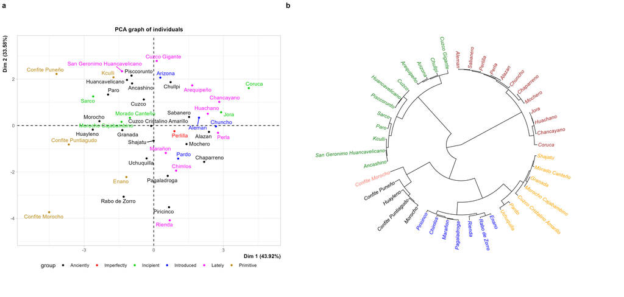

```r
hc <- cls$call$t$tree
k <- length(unique(cls$data.clust$clust))
clus <- cutree(hc, k)

colors <- c("salmon", "black", "forestgreen", "orange", "blue", "brown")

clsp_fan <- function() {

  plot(as.phylo(hc)
     , type = "fan"
     , tip.color = colors[clus]
     , label.offset = 0.01
     , cex = 0.8)
}

clsp <- \() {

  plot.HCPC(cls, choice = "map", draw.tree = F) # tree?

}

plot <- c(ind, clsp_fan) %>%
  plot_grid(plotlist = ., nrow = 1, labels = "auto"
            , rel_widths = c(1, 1.2)) %>%
  ggsave2("manuscript/Figure-3.jpg"
          , plot = .
          , width =42 , height = 20
          , units = "cm")

plot %>% include_graphics()
```

# 7 References

Broman, K. W., & Woo, K. H. (2017). Data organization in spreadsheets. The American Statistician, 72(1), 2–10. https://doi.org/10.1080/00031305.2017.1375989

Zuur, A. F., Ieno, E. N., & Elphick, C. S. (2009). A protocol for data exploration to avoid common statistical problems. Methods in Ecology and Evolution, 1(1), 3–14. https://doi.org/10.1111/j.2041-210x.2009.00001.x

Francoishusson. (2017, July 13). PCA course using FactoMineR | R-bloggers. R-bloggers. https://www.r-bloggers.com/2017/07/pca-course-using-factominer/

Kozak, M., & Piepho, H. (2017). What’s normal anyway? Residual plots are more telling than significance tests when checking ANOVA assumptions. Journal of Agronomy and Crop Science, 204(1), 86–98. https://doi.org/10.1111/jac.12220

Tanaka, E., & Hui, F. K. C. (2019). Symbolic formulae for linear mixed models. In Communications in computer and information science (pp. 3–21). https://doi.org/10.1007/978-981-15-1960-4_1

Schielzeth, H., Dingemanse, N. J., Nakagawa, S., Westneat, D. F., Allegue, H., Teplitsky, C., Réale, D., Dochtermann, N. A., Garamszegi, L. Z., & Araya‐Ajoy, Y. G. (2020). Robustness of linear mixed‐effects models to violations of distributional assumptions. Methods in Ecology and Evolution, 11(9), 1141–1152. https://doi.org/10.1111/2041-210x.13434